# Group_1_Project

Matthew Runyon, Winston Wong, & Leo D’Agostino

10/16/2020

The data set that we have chosen to work with is the “Volcano Eruptions” data set, coming from Week 20 of the 2020 TidyTuesday project. This data is provided by the Smithsonian Institute. The data, which is split into five files (`volcano`, `eruptions`, `events`, `tree_rings`, and `sulfur`). As far as responsibilities for each of these files, Winston was responsible for data analysis on the `tree_rings` and `sulfur` data sets, Leo was responsible for investigating the `eruptions` data set, and Matthew was responsible for analyzing the `volcano` data set. Everyone provided assistance across data sets with code formatting to bolster the appearance after preliminary analyses had been completed independently. We chose not to delve into the `events` file because it was mainly date information without many other important variables to work with.

**NOTE**: This HTML document contains all the code neccesary for saving the tables and figures for the primary document composer (Matthew Runyon) on a local machine, noted by the creation of the file paths in the second half of this chunk of code. However, this code was causing issues in knitting for the other members of the group. This document is simply provided to show how the figures were saved without error. Once the saved figures have been pushed to Github, this code will be removed in the final document to prevent additional errors in knitting.

```r
volcano <- readr::read_csv('https://raw.githubusercontent.com/rfordatascience/tidytuesday/master/data/2020/2020-05-12/volcano.csv')
eruptions <- readr::read_csv('https://raw.githubusercontent.com/rfordatascience/tidytuesday/master/data/2020/2020-05-12/eruptions.csv')
events <- readr::read_csv('https://raw.githubusercontent.com/rfordatascience/tidytuesday/master/data/2020/2020-05-12/events.csv')
tree_rings <- readr::read_csv('https://raw.githubusercontent.com/rfordatascience/tidytuesday/master/data/2020/2020-05-12/tree_rings.csv')
sulfur <- readr::read_csv('https://raw.githubusercontent.com/rfordatascience/tidytuesday/master/data/2020/2020-05-12/sulfur.csv')
```

```r
data_sets_path<-"C:/Users/mrunyon2/Documents/Classes/Fall 2020/CPSC 441/Group_1/Data_Sets"
figure_path<-"C:/Users/mrunyon2/Documents/Classes/Fall 2020/CPSC 441/Group_1/Figures"
summary_text_path<-"C:/Users/mrunyon2/Documents/Classes/Fall 2020/CPSC 441/Group_1/Summary_Text_files"

write.table(volcano, file.path(data_sets_path, "volcano.txt"))
write.table(eruptions, file.path(data_sets_path, "eruptions.txt"))
write.table(events, file.path(data_sets_path, "events.txt"))
write.table(tree_rings, file.path(data_sets_path, "tree_rings.txt"))
write.table(sulfur, file.path(data_sets_path, "sulfur.txt"))
```

**Loading Relevant Packages**

Here we load all of the relevant packages that will be used with our project. This ensures that all packages will be loaded at the start so that there is no redundancy within the code.

```r
library(tidyverse)
library(car)
library(ggpubr)
library(threejs)
library(qwraps2)
library(agricolae)
```

**Sulfur Concentration Dataset**

The sulfur concentration data set contains three variables. Two are sulfur content in ng/g collected from NEEM and WDC ice cores, which were collected from Greenland and Antarctica, respectively. These are treated as the response variables. The independent variable is the year, which is approximated as the time that the sulfur depositions took place.

*Summary Statistics and Means*

First, we are presenting summary statistics of this data. This is done by constructing a summary table based on the `qwraps2` package. Then, we save the means of the data set in a separate text file using the code below. Since there are only two numeric variables in this data set, this is not a large file on its own.

```r
sulfur_summary <-
  list("NEEM" =
       list("min_neem"       = ~ min(sulfur$neem, na.rm=T),
            "max_neem"       = ~ max(sulfur$neem, na.rm=T),
            "median_neem"    = ~ median(sulfur$neem, na.rm=T),
            "mean_neem"      = ~ mean(sulfur$neem, na.rm=T),
            "variance_neem"  = ~ var(sulfur$neem, na.rm=T),
            "stdev_neem"     = ~ sd(sulfur$neem, na.rm=T)),
       "WDC" =
       list("min_wdc"       = ~ min(sulfur$wdc, na.rm=T),
            "max_wdc"       = ~ max(sulfur$wdc, na.rm=T),
            "median_wdc"    = ~ median(sulfur$wdc, na.rm=T),
            "mean_wdc"      = ~ mean(sulfur$wdc, na.rm=T),
            "variance_wdc"  = ~ var(sulfur$wdc, na.rm=T),
            "stdev_wdc"     = ~ sd(sulfur$wdc, na.rm=T))
       )
sulfur_summary_table<-as.data.frame(summary_table(sulfur, summaries=sulfur_summary))
sulfur_summary_table
```

```
##               sulfur (N = 2,252)
## min_neem                1.070000
## max_neem              170.600000
## median_neem            13.270000
## mean_neem              16.461794
## variance_neem         202.473765
## stdev_neem             14.229328
## min_wdc                 3.745800
## max_wdc                72.871000
## median_wdc             12.805000
## mean_wdc               14.122158
## variance_wdc           45.760693
## stdev_wdc               6.764665
```

```r
sulfur_means<-data.frame(mean(sulfur$neem, na.rm=T), mean(sulfur$wdc, na.rm=T))
names(sulfur_means)<-c("NEEM_mean", "WDC_mean")
row.names(sulfur_means)<-c("overall_mean_sulfur_content")
write.table(sulfur_means, file.path(summary_text_path, "sulfur_dataset_overall_means.txt"))
```

Plotted below is a simple line graph showing sulfur concentration in ice cores across years of deposition. We can see several major spikes in sulfur content, which are indicative of volcanic eruptions that have sent high-sulfur ash into the air. Notable peaks in the NEEM core data are around 525 AD, 540 AD, 575 AD, 625 AD, and 685 AD, while notable peaks in the WDC core data are around 550 AD, 575 AD, and 685 AD. For several of these major peaks, there appears to be overlap between the data sets. This is particularly interesting because these would signify major volcanic eruptions, as cores were pulled from ice samples near poles at opposite ends of the world.

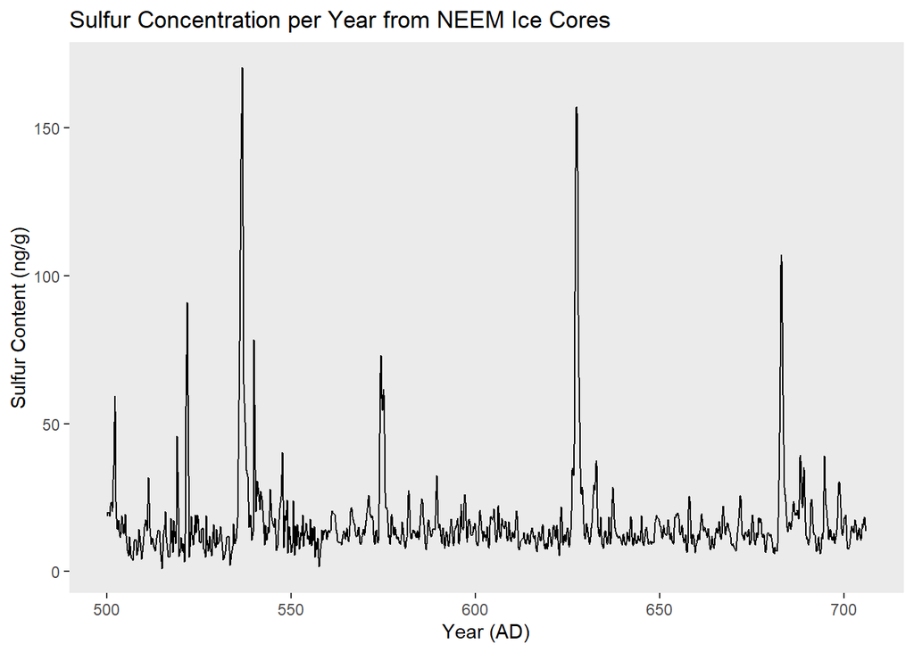

```r
ggplot(sulfur, aes(x=year, y=neem))+
  geom_line()+
  ggtitle("Sulfur Concentration per Year from NEEM Ice Cores")+
  labs(x="Year (AD)", y="Sulfur Content (ng/g)")+
  theme(panel.grid=element_blank())+
  ggsave(file.path(figure_path, "neem_sulfur_across_years.pdf"))
```

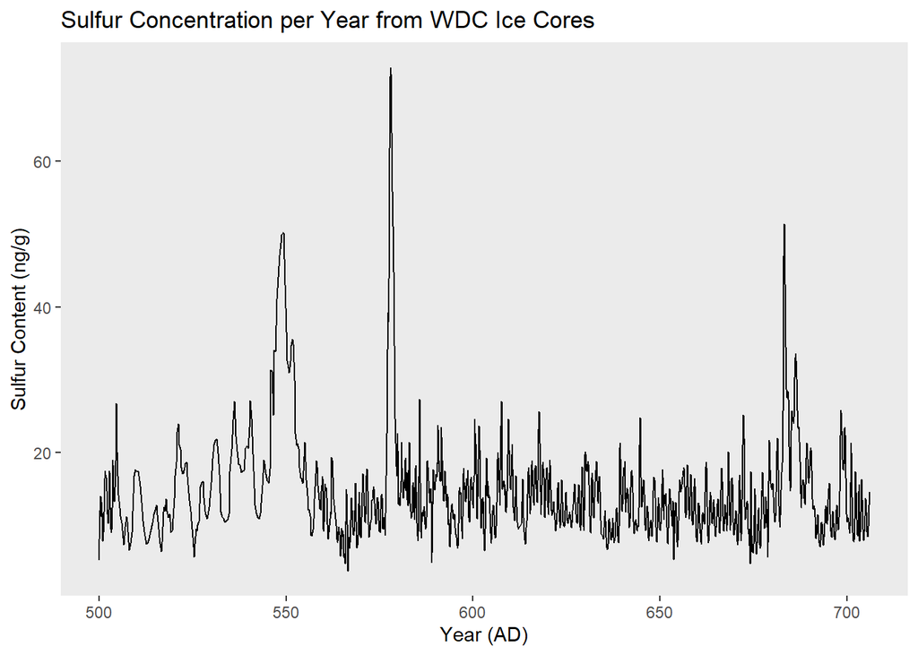

```r
ggplot(sulfur, aes(x=year, y=wdc))+
  geom_line()+
  ggtitle("Sulfur Concentration per Year from WDC Ice Cores")+
  labs(x="Year (AD)", y="Sulfur Content (ng/g)")+
  theme(panel.grid=element_blank())+
  ggsave(file.path(figure_path, "wdc_sulfur_across_years.pdf"))
```

*Linear Regression Analysis of Sulfur Content vs. Year and NEEM vs. WDC Sulfur Content*

Here, we conduct linear regression to evaluate whether there is a significant linear relationship between year and sulfur content in either of the two locations.

First we will construct the model, then we will evaluate the assumptions to see if building that model is appropriate for this data set. Building a linear model allows us to establish a relationship between year and sulfur levels at NEEM and WDC locations in the form of sulfur levels as a function for year. Null and alternative hypotheses for each of the models are provided, followed by linear models themselves for sulfur levels at both locations are shown below. Slope and intercept values are provided upon calling the model.

```r
#Linear model for Sulfur levels at NEEM
#Ho: Slope = 0 (no linear relationship)
#HA: Slope not equal to 0 (linear relationship)
NEEM_linear_model <- lm(neem ~ year, data = sulfur)
NEEM_linear_model
```

```
##
## Call:
## lm(formula = neem ~ year, data = sulfur)
##
## Coefficients:
## (Intercept)         year
##   19.886023    -0.005519
```

```r
#Linear model for Sulfur levels at WDC
#Ho: Slope = 0 (no linear relationship)
#HA: Slope not equal to 0 (linear relationship)
WDC_linear_model <- lm(wdc ~ year, data = sulfur)
WDC_linear_model
```

```
##
## Call:
## lm(formula = wdc ~ year, data = sulfur)
##
## Coefficients:
## (Intercept)         year
##    21.02073     -0.01072
```

```r
#Linear model for NEEM vs. WDC
#Ho: Slope = 0 (no linear relationship)
#HA: Slope not equal to 0 (linear relationship)
NEEMvsWDC_linear_model <-lm(wdc~neem, data = sulfur)
NEEMvsWDC_linear_model
```

```
##
## Call:
## lm(formula = wdc ~ neem, data = sulfur)
##
## Coefficients:
## (Intercept)         neem
##    13.35411      0.06182
```

After forming these three linear models, we can to test for correlation between year vs. sulfur concentrations in both locations and correlation between NEEM and WDC sulfur content. We will test for correlation using the Pearson’s “r”. Based off of these values, we can conclude that there is an extremely weak linear correlation among the variables of interest, negative for the first two models and positive for the third.

```r
#Year vs NEEM
cor(sulfur$year, sulfur$neem, method = "pearson", use = "complete.obs")
```

```
## [1] -0.02067614
```

```r
#Year vs WDC
cor(sulfur$year, sulfur$wdc, method = "pearson", use = "complete.obs")
```

```
## [1] -0.08085896
```

```r
#NEEM vs WDC
cor(sulfur$neem, sulfur$wdc, method = "pearson", use = "complete.obs")
```

```
## [1] 0.1245037
```

By running the `summary()` below function, we can determine the significance of our models. Our conclusions are noted as follows:

1. Year vs NEEM: p = 0.36. At alpha = 0.05, we fail to reject the null hypothesis and conclude that no significant linear relationship exists between year and NEEM sulfur content.
2. Year vs WDC: p = 0.0003. At alpha = 0.05, we reject the null hypothesis and conclude that there is a significant linear relationship between year and WDC sulfur content.
3. NEEM vs WDC: p = 3.2 x 10E-8. At alpha = 0.05, we reject the null hypothesis and conclude that there is a significant linear relationship between sulfur content at NEEM and WDC.

```r
#model summary for sulfur levels at NEEM
summary(NEEM_linear_model)
```

```
##
## Call:
## lm(formula = neem ~ year, data = sulfur)
##
## Residuals:
##     Min      1Q  Median      3Q     Max
## -15.974  -5.578  -3.197   0.789 153.676
##
## Coefficients:
##              Estimate Std. Error t value Pr(>|t|)
## (Intercept) 19.886023   3.753780   5.298 1.31e-07 ***
## year        -0.005519   0.006028  -0.916     0.36
## ---
## Signif. codes:  0 '***' 0.001 '**' 0.01 '*' 0.05 '.' 0.1 ' ' 1
##
## Residual standard error: 14.23 on 1960 degrees of freedom
##   (290 observations deleted due to missingness)
## Multiple R-squared:  0.0004275,  Adjusted R-squared:  -8.248e-05
## F-statistic: 0.8383 on 1 and 1960 DF,  p-value: 0.36
```

```r
#model summary for sulfur levels at WDC
summary(WDC_linear_model)
```

```
##
## Call:
## lm(formula = wdc ~ year, data = sulfur)
##
## Residuals:
##     Min      1Q  Median      3Q     Max
## -11.203  -3.942  -1.397   1.946  58.044
##
## Coefficients:
##              Estimate Std. Error t value Pr(>|t|)
## (Intercept) 21.020729   1.858107  11.313  < 2e-16 ***
## year        -0.010717   0.002984  -3.592 0.000337 ***
## ---
## Signif. codes:  0 '***' 0.001 '**' 0.01 '*' 0.05 '.' 0.1 ' ' 1
##
## Residual standard error: 7.044 on 1960 degrees of freedom
##   (290 observations deleted due to missingness)
## Multiple R-squared:  0.006538,   Adjusted R-squared:  0.006031
## F-statistic:  12.9 on 1 and 1960 DF,  p-value: 0.0003368
```

```r
#model summary for NEEM vs. WDC
summary(NEEMvsWDC_linear_model)
```

```
##
## Call:
## lm(formula = wdc ~ neem, data = sulfur)
##
## Residuals:
##     Min      1Q  Median      3Q     Max
## -11.634  -4.003  -1.400   2.026  58.692
##
## Coefficients:
##             Estimate Std. Error t value Pr(>|t|)
## (Intercept) 13.35411    0.24211  55.158  < 2e-16 ***
## neem         0.06182    0.01113   5.555 3.15e-08 ***
## ---
## Signif. codes:  0 '***' 0.001 '**' 0.01 '*' 0.05 '.' 0.1 ' ' 1
##
## Residual standard error: 7.012 on 1960 degrees of freedom
##   (290 observations deleted due to missingness)
## Multiple R-squared:  0.0155, Adjusted R-squared:  0.015
## F-statistic: 30.86 on 1 and 1960 DF,  p-value: 3.151e-08
```

Now that we have constructed models and determined that a linear relationship was observed for two of the three models, we need to test the assumptions to determine whether linear regression was appropriate for this data. We can first create scatter plots to visualize a possible linear relationship between the independent and dependent variables. From the scatterplot it does not appear that there is a linear relationship between year and sulfur concentration at either location, nor between the two sulfur contents. Under normal circumstances, we would conclude that linear regression is inappropriate because there doesn’t appear to be visual linear trend; nonetheless, for demonstration purposes, we are continuing with the process. We demonstrate the correlation coefficient and significance level on the charts using the `stat_cor()` function from the `ggpubr` package, as well as a confidence interval using the `geom_smooth()` function. We will continue to check the assumptions for demonstration purposes.

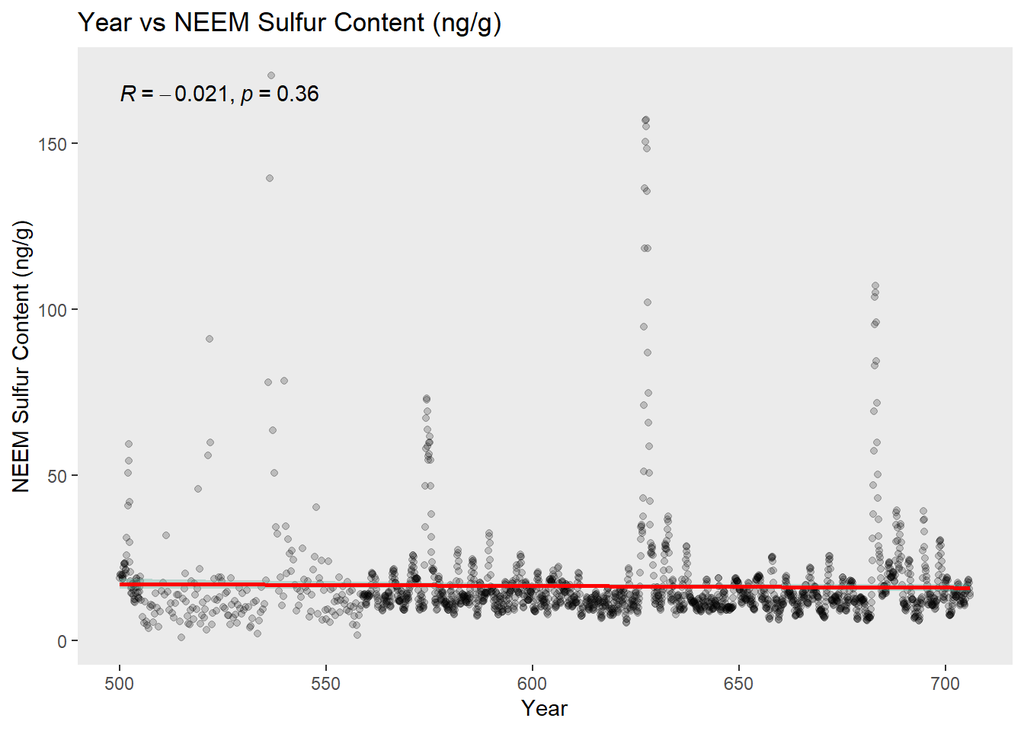

```r
ggplot(sulfur, aes(x=year, y=neem))+
  geom_point(alpha=1/5)+
  ggtitle("Year vs NEEM Sulfur Content (ng/g)")+
  labs(x="Year", y="NEEM Sulfur Content (ng/g)")+
  theme(panel.grid=element_blank())+
  stat_cor()+
  geom_smooth(method=lm , color="red", fill="#69b3a2", se=TRUE)+
  ggsave(file.path(figure_path, "year_vs_neem_correlation.pdf"))
```

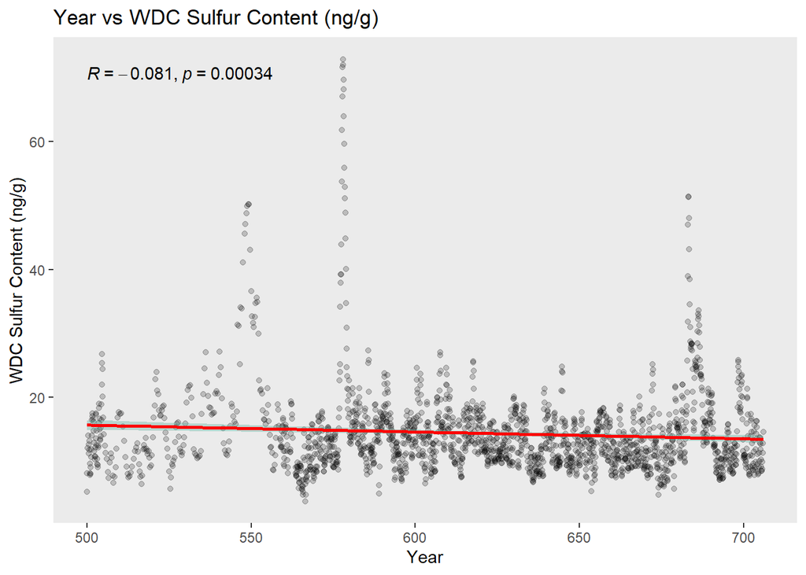

```r
ggplot(sulfur, aes(x=year, y=wdc))+
  geom_point(alpha=1/5)+
  ggtitle("Year vs WDC Sulfur Content (ng/g)")+
  labs(x="Year", y="WDC Sulfur Content (ng/g)")+
  theme(panel.grid=element_blank())+
  stat_cor()+
  geom_smooth(method=lm , color="red", fill="#69b3a2", se=TRUE)+
  ggsave(file.path(figure_path, "year_vs_wdc_correlation.pdf"))
```

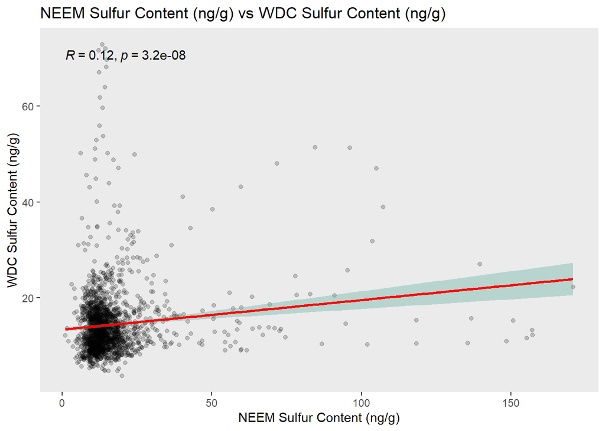

```r
ggplot(sulfur, aes(x=neem, y=wdc))+
  geom_point(alpha=1/5)+
  ggtitle("NEEM Sulfur Content (ng/g) vs WDC Sulfur Content (ng/g)")+
  labs(x="NEEM Sulfur Content (ng/g)", y="WDC Sulfur Content (ng/g)")+
  theme(panel.grid=element_blank())+
  stat_cor()+
  geom_smooth(method=lm , color="red", fill="#69b3a2", se=TRUE)+
  ggsave(file.path(figure_path, "neem_vs_wdc_correlation.pdf"))
```

Next, we can create boxplots to check for outliers for the variables `neem` and `wdc` sulfur concentrations. From both boxplots, we conclude that there are many outliers, and that the data from both data sets is heavily right skewed and not normally distributed. If we look instead at the residuals from each of the models, we can see that the residuals are likewise heavily right skewed and not normally distributed. Again in this case, this would normally disqualify us from carrying out linear regression.

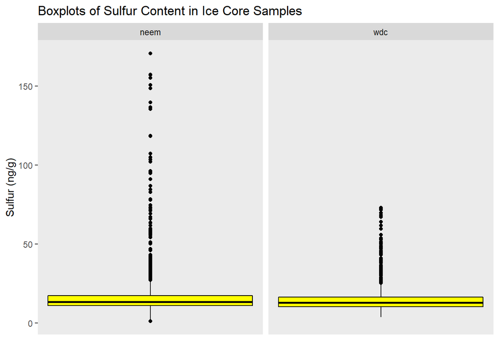

```r
sulfur_long<-pivot_longer(sulfur, cols=c("neem", "wdc"), names_to="core_loc")
sulfur_long$core_loc<-as.factor(sulfur_long$core_loc)
write.table(sulfur_long, file.path(data_sets_path, "sulfur_dataset_pivot_long.txt"))

#Boxplots for distribution of raw data
ggplot(sulfur_long, aes(x=year, y=value))+
  geom_boxplot(col="black", fill="yellow")+
  ggtitle("Boxplots of Sulfur Content in Ice Core Samples")+
  labs(y="Sulfur (ng/g)", x="")+
  theme(panel.grid=element_blank(), axis.text.x=element_blank(), axis.ticks.x=element_blank())+
  facet_wrap(~core_loc)+
  ggsave(file.path(figure_path, "sulfur_distribution_boxplot.pdf"))
```

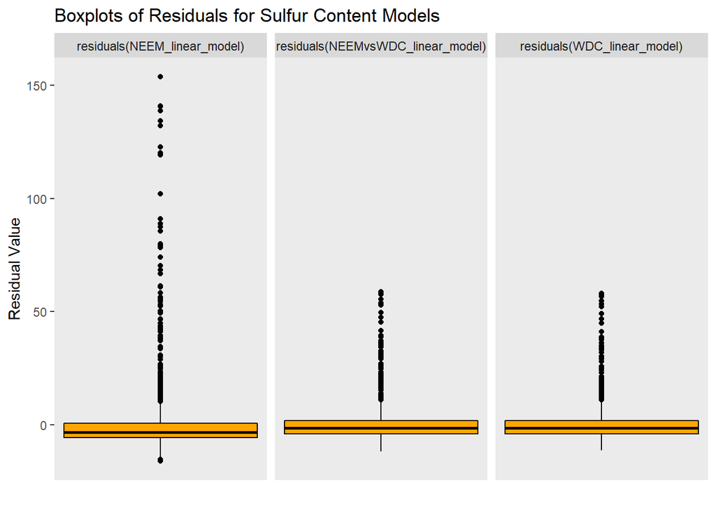

```r
#Boxplots for distribution of residuals
neem_res<-as.data.frame(residuals(NEEM_linear_model))
wdc_res<-as.data.frame(residuals(WDC_linear_model))
neem_vs_wdc_res<-as.data.frame(residuals(NEEMvsWDC_linear_model))
sulfur_residuals<-cbind(neem_res, wdc_res, neem_vs_wdc_res)
sulfur_residuals_long<-pivot_longer(sulfur_residuals, cols=c("residuals(NEEM_linear_model)", "residuals(WDC_linear_model)", "residuals(NEEMvsWDC_linear_model)"), names_to="residual")

ggplot(sulfur_residuals_long, aes(y=value))+
  geom_boxplot(col="black", fill="orange")+
  ggtitle("Boxplots of Residuals for Sulfur Content Models")+
  labs(y="Residual Value", x="")+
  theme(panel.grid=element_blank(), axis.text.x=element_blank(), axis.ticks.x=element_blank())+
  facet_wrap(~residual)+
  ggsave(file.path(figure_path, "sulfur_resiudals_distribution_boxplot.pdf"))
```

Overall, even though we demonstrated that the Year vs WDC and NEEM vs WDC models were statistically significant, we have shown through testing the assumptions that linear regression is not an appropriate approach to take with this data set due to extreme non-normality and lack of a suggestive visible linear trend. Therefore, if we were to look at these variables in a more detailed approach, a data tranformation should be attempted, or an approach other than linear regression should be taken to test for relationship between these variables.

**Tree Ring Dataset**

Like the sulfur dataset, the tree ring data set contains three variables. Two response variables are the European temperature index and tree ring Z-scores. The European temperature index is a relative temperature index in degrees Celsius. The more ash that is spewed into the air from volcanic eruptions, the more sunlight should be reflected in the atmosphere, and the cooler the average temperature for a given year should be. Likewise, temperature and seasonal extremes should cause more variability in vegetative growth such as tree rings, and this variability should be reflected by larger Z scores. The independent variable is the year from which these measurements were taken, dating back 2,000 years.

*Summary Statistics and Means*

First, we present summary statistics of this data. As done with the sulfur data set, this is done by constructing a summary table based on the `qwraps2` package. Then, we save the means of the data set in a separate text file using the code below. Again, there are only two numeric values in this data file.

```r
tree_ring_summary <-
  list("n_tree" =
         list("min_n_tree"       = ~ min(tree_rings$n_tree, na.rm=T),
              "max_n_tree"       = ~ max(tree_rings$n_tree, na.rm=T),
              "median_n_tree"    = ~ median(tree_rings$n_tree, na.rm=T),
              "mean_n_tree"      = ~ mean(tree_rings$n_tree, na.rm=T),
              "variance_n_tree"  = ~ var(tree_rings$n_tree, na.rm=T),
              "stdev_n_tree"     = ~ sd(tree_rings$n_tree, na.rm=T)),
       "europe_temp_index" =
         list("min_europe_temp_index"       = ~ min(tree_rings$europe_temp_index, na.rm=T),
              "max_europe_temp_index"       = ~ max(tree_rings$europe_temp_index, na.rm=T),
              "median_europe_temp_index"    = ~ median(tree_rings$europe_temp_index, na.rm=T),
              "mean_europe_temp_index"      = ~ mean(tree_rings$europe_temp_index, na.rm=T),
              "variance_europe_temp_index"  = ~ var(tree_rings$europe_temp_index, na.rm=T),
              "stdev_europe_temp_index"     = ~ sd(tree_rings$europe_temp_index, na.rm=T))
  )
tree_ring_summary_table<-as.data.frame(summary_table(tree_rings, summaries=tree_ring_summary))
tree_ring_summary_table
```

```
##                            tree_rings (N = 2,252)
## min_n_tree                             -3.2900000
## max_n_tree                              2.2600000
## median_n_tree                          -0.5300000
## mean_n_tree                            -0.5511750
## variance_n_tree                         0.5139509
## stdev_n_tree                            0.7169037
## min_europe_temp_index                  -1.7300000
## max_europe_temp_index                   1.5300000
## median_europe_temp_index               -0.1600000
## mean_europe_temp_index                 -0.1650050
## variance_europe_temp_index              0.1994563
## stdev_europe_temp_index                 0.4466053
```

```r
tree_ring_means<-data.frame(mean(tree_rings$n_tree, na.rm=T), mean(tree_rings$europe_temp_index, na.rm=T))
names(tree_ring_means)<-c("n_tree_mean", "europe_temp_index_mean")
row.names(tree_ring_means)<-c("overall_means")
write.table(tree_ring_means, file.path(summary_text_path, "tree_ring_dataset_overall_means.txt"))
```

Plotted below are two line graphs showing the measurements of tree ring Z-scores and the European temperature index over time. As shown in these two graphs, the data is very noisy, with large swings from year to year. It is much more noisy than the ice core data. This likely is due to the imprecision of these measurements; since these date back before records were being taken and the data isn’t preserved as exactly in time like it is for the sulfur in the ice cores, there is a lot more room for error from these estimations.

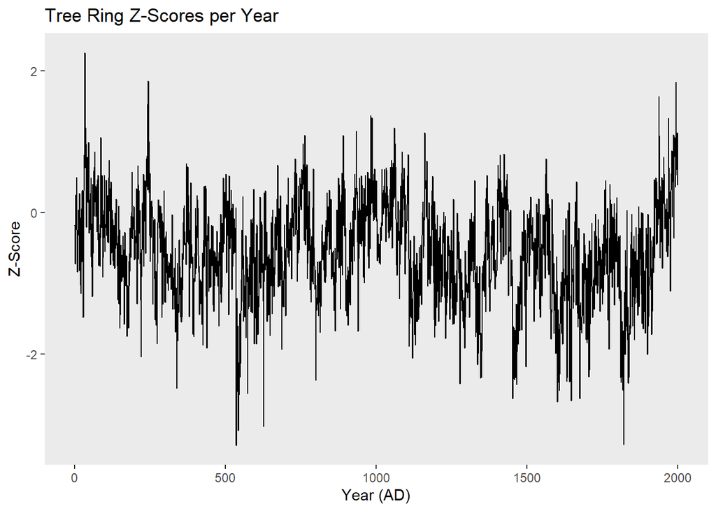

```r
ggplot(tree_rings, aes(x=year, y=n_tree))+
  geom_line()+
  ggtitle("Tree Ring Z-Scores per Year")+
  labs(x="Year (AD)", y="Z-Score")+
  theme(panel.grid=element_blank())+
  ggsave(file.path(figure_path, "tree_ring_scores_across_years.pdf"))
```

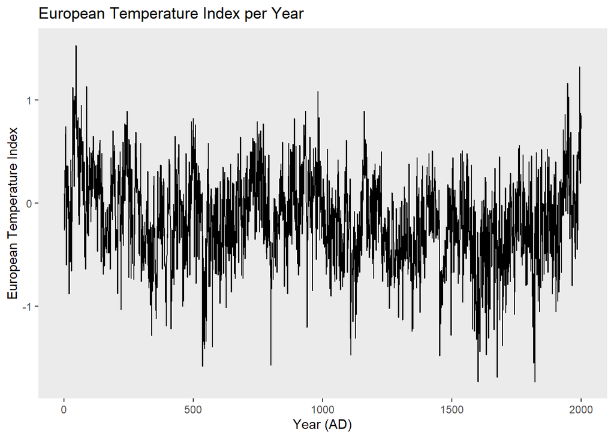

```r
ggplot(tree_rings, aes(x=year, y=europe_temp_index))+
  geom_line()+
  ggtitle("European Temperature Index per Year")+
  labs(x="Year (AD)", y="European Temperature Index")+
  theme(panel.grid=element_blank())+
  ggsave(file.path(figure_path, "temp_index_across_years.pdf"))
```

Here, we conduct linear regression to evaluate whether there is a significant linear relationship between year and tree ring Z-score, year and temperature index, and tree ring Z-score and temperature index.

First we will construct the representative models, then we will evaluate the assumptions to see if building that model is appropriate for this data set. Null and alternative hypotheses for each of the models are provided, followed by linear models themselves are shown below. Slope and intercept values are provided upon calling the model.

```r
#Linear model for year vs "n_tree"
#Ho: Slope = 0 (no linear relationship)
#HA: Slope not equal to 0 (linear relationship)
nTree_linear_model <- lm(n_tree ~ year, data = tree_rings)
nTree_linear_model
```

```
##
## Call:
## lm(formula = n_tree ~ year, data = tree_rings)
##
## Coefficients:
## (Intercept)         year
##  -0.3668420   -0.0001842
```

```r
#Linear model for year vs. "europe_temp_index"
#Ho: Slope = 0 (no linear relationship)
#HA: Slope not equal to 0 (linear relationship)
ETI_linear_model <- lm(europe_temp_index ~ year, data = tree_rings)
ETI_linear_model
```

```
##
## Call:
## lm(formula = europe_temp_index ~ year, data = tree_rings)
##
## Coefficients:
## (Intercept)         year
##  -0.0067512   -0.0001582
```

```r
#Linear model for "n_tree" vs. "europe_temp_index
#Ho: Slope = 0 (no linear relationship)
#HA: Slope not equal to 0 (linear relationship)
nTreevsETI_linear_model <-lm(europe_temp_index~n_tree, data = tree_rings)
nTreevsETI_linear_model
```

```
##
## Call:
## lm(formula = europe_temp_index ~ n_tree, data = tree_rings)
##
## Coefficients:
## (Intercept)       n_tree
##      0.1073       0.4941
```

```r
#Year vs n_tree
cor(tree_rings$year, tree_rings$n_tree, method = "pearson", use = "complete.obs")
```

```
## [1] -0.1484134
```

```r
#Year vs europe_temp_index
cor(tree_rings$year, tree_rings$europe_temp_index, method = "pearson", use = "complete.obs")
```

```
## [1] -0.2045319
```

```r
#n_tree vs europe_temp_index
cor(tree_rings$n_tree, tree_rings$europe_temp_index, method = "pearson", use = "complete.obs")
```

```
## [1] 0.7931274
```

By running the `summary()` below function, we can determine the significance of our models. Our conclusions are noted as follows:

1. Year vs n_tree: p = 2.6E-11. At alpha = 0.05, we reject the null hypothesis and conclude that there is a significant linear relationship between year and tree ring Z-score.
2. Year vs europe_temp_index: p = 2.2E-16. At alpha = 0.05, we reject the null hypothesis and conclude that there is a significant linear relationship between year and European temperature index.
3. n_tree vs europe_temp_index: p = 2.2E-16. At alpha = 0.05, we reject the null hypothesis and conclude that there is a significant linear relationship between tree ring Z-score and European temperature index.

```r
#model summary for "n_tree" and year
summary(nTree_linear_model)
```

```
##
## Call:
## lm(formula = n_tree ~ year, data = tree_rings)
##
## Residuals:
##      Min       1Q   Median       3Q      Max
## -2.82440 -0.44884  0.00739  0.49246  2.63329
##
## Coefficients:
##               Estimate Std. Error t value Pr(>|t|)
## (Intercept) -3.668e-01  3.173e-02 -11.563  < 2e-16 ***
## year        -1.842e-04  2.746e-05  -6.708 2.56e-11 ***
## ---
## Signif. codes:  0 '***' 0.001 '**' 0.01 '*' 0.05 '.' 0.1 ' ' 1
##
## Residual standard error: 0.7091 on 1998 degrees of freedom
##   (252 observations deleted due to missingness)
## Multiple R-squared:  0.02203,    Adjusted R-squared:  0.02154
## F-statistic:    45 on 1 and 1998 DF,  p-value: 2.557e-11
```

```r
#model summary for "europe_temp_index" and year
summary(ETI_linear_model)
```

```
##
## Call:
## lm(formula = europe_temp_index ~ year, data = tree_rings)
##
## Residuals:
##      Min       1Q   Median       3Q      Max
## -1.48847 -0.28399 -0.00102  0.29584  1.64215
##
## Coefficients:
##               Estimate Std. Error t value Pr(>|t|)
## (Intercept) -6.751e-03  1.956e-02  -0.345     0.73
## year        -1.582e-04  1.694e-05  -9.340   <2e-16 ***
## ---
## Signif. codes:  0 '***' 0.001 '**' 0.01 '*' 0.05 '.' 0.1 ' ' 1
##
## Residual standard error: 0.4373 on 1998 degrees of freedom
##   (252 observations deleted due to missingness)
## Multiple R-squared:  0.04183,    Adjusted R-squared:  0.04135
## F-statistic: 87.23 on 1 and 1998 DF,  p-value: < 2.2e-16
```

```r
#model summary for "n_tree" vs. "europe_temp_index"
summary(nTreevsETI_linear_model)
```

```
##
## Call:
## lm(formula = europe_temp_index ~ n_tree, data = tree_rings)
##
## Residuals:
##      Min       1Q   Median       3Q      Max
## -1.27898 -0.17062  0.00602  0.18306  1.12057
##
## Coefficients:
##             Estimate Std. Error t value Pr(>|t|)
## (Intercept) 0.107325   0.007675   13.98   <2e-16 ***
## n_tree      0.494090   0.008488   58.21   <2e-16 ***
## ---
## Signif. codes:  0 '***' 0.001 '**' 0.01 '*' 0.05 '.' 0.1 ' ' 1
##
## Residual standard error: 0.2721 on 1998 degrees of freedom
##   (252 observations deleted due to missingness)
## Multiple R-squared:  0.6291, Adjusted R-squared:  0.6289
## F-statistic:  3388 on 1 and 1998 DF,  p-value: < 2.2e-16
```

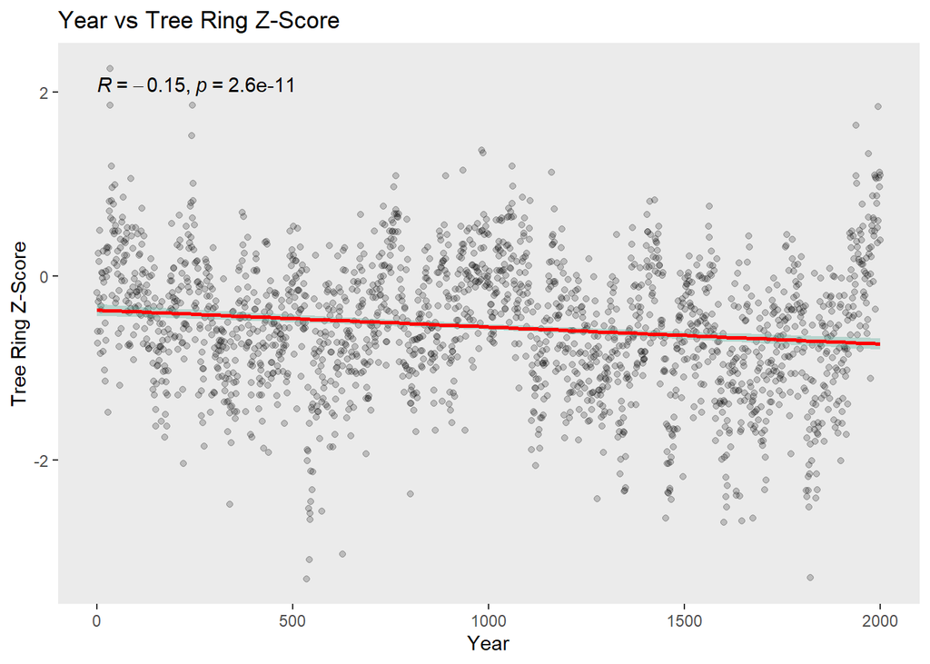

```r
ggplot(tree_rings, aes(x=year, y=n_tree))+
  geom_point(alpha=1/5)+
  ggtitle("Year vs Tree Ring Z-Score")+
  labs(x="Year", y="Tree Ring Z-Score")+
  theme(panel.grid=element_blank())+
  stat_cor()+
  geom_smooth(method=lm , color="red", fill="#69b3a2", se=TRUE)+
  ggsave(file.path(figure_path, "year_vs_tree_ring_correlation.pdf"))
```

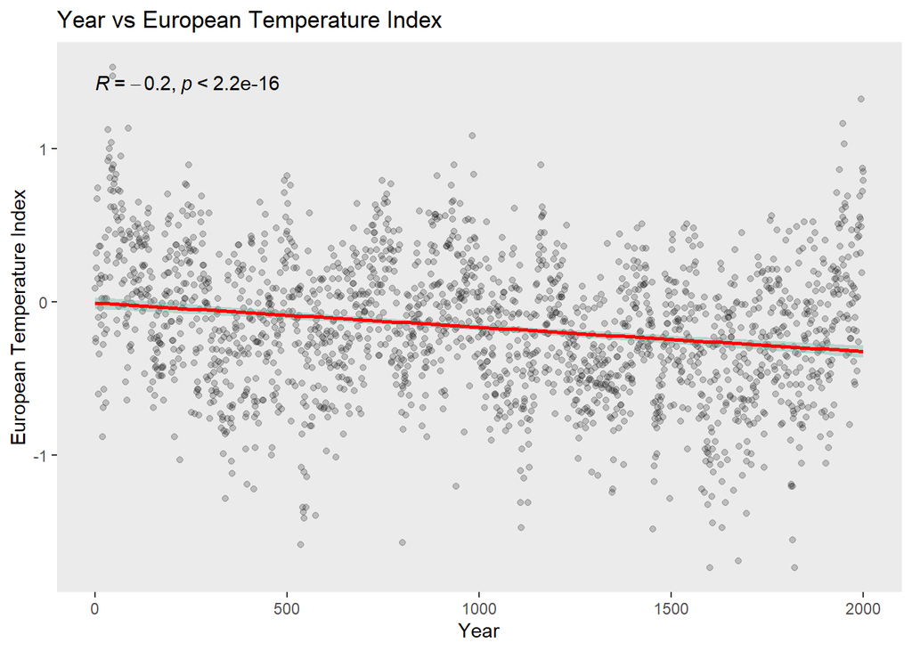

```r
ggplot(tree_rings, aes(x=year, y=europe_temp_index))+
  geom_point(alpha=1/5)+
  ggtitle("Year vs European Temperature Index")+
  labs(x="Year", y="European Temperature Index")+
  theme(panel.grid=element_blank())+
  stat_cor()+
  geom_smooth(method=lm , color="red", fill="#69b3a2", se=TRUE)+
  ggsave(file.path(figure_path, "year_vs_temp_index_correlation.pdf"))
```

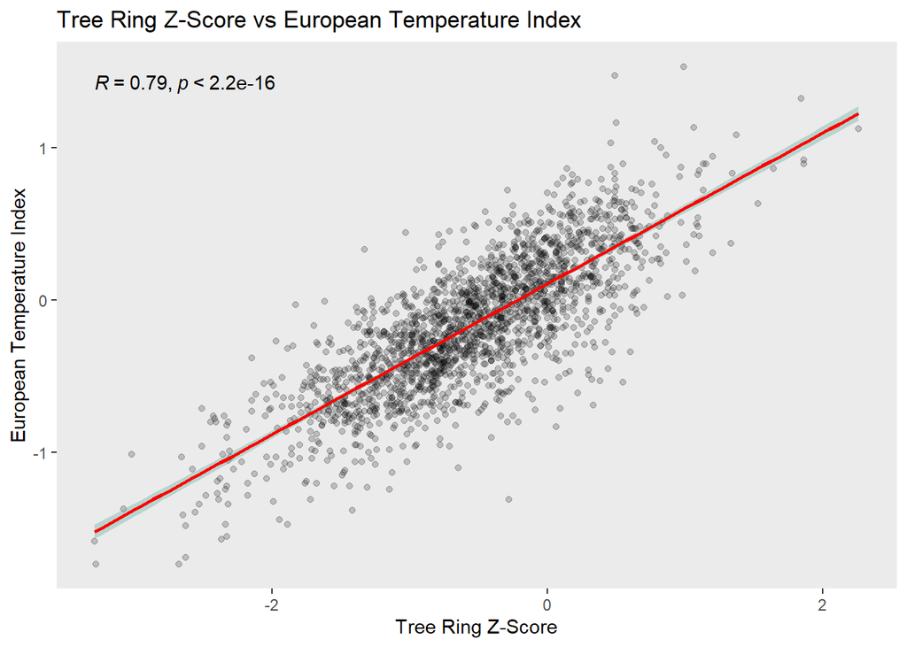

```r
ggplot(tree_rings, aes(x=n_tree, y=europe_temp_index))+
  geom_point(alpha=1/5)+
  ggtitle("Tree Ring Z-Score vs European Temperature Index")+
  labs(x="Tree Ring Z-Score", y="European Temperature Index")+
  theme(panel.grid=element_blank())+
  stat_cor()+
  geom_smooth(method=lm , color="red", fill="#69b3a2", se=TRUE)+
  ggsave(file.path(figure_path, "tree_ring_vs_temp_index_correlation.pdf"))
```

Next, we can create boxplots to check for outliers for the variables `n_tree` and `europe_temp_index` values. From both boxplots, we conclude that there are several outliers, but the data from both data appears normally distributed without skew. If we look instead at the residuals from each of the models, they also appear to follow a normal distribution for all three of the models. From this data, we can conclude that this assumption has been met.

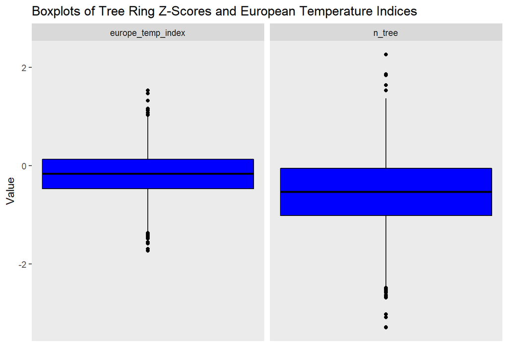

```r
tree_rings_long<-pivot_longer(tree_rings, cols=c("n_tree", "europe_temp_index"), names_to="measurement_type")
tree_rings_long$measurement_type<-as.factor(tree_rings_long$measurement_type)
write.table(tree_rings_long, file.path(data_sets_path, "tree_rings_dataset_pivot_long.txt"))

#Boxplots for distribution of raw data
ggplot(tree_rings_long, aes(x=year, y=value))+
  geom_boxplot(col="black", fill="blue")+
  ggtitle("Boxplots of Tree Ring Z-Scores and European Temperature Indices")+
  labs(y="Value", x="")+
  theme(panel.grid=element_blank(), axis.text.x=element_blank(), axis.ticks.x=element_blank())+
  facet_wrap(~measurement_type)+
  ggsave(file.path(figure_path, "tree_ring_temp_index_distribution_boxplot.pdf"))
```

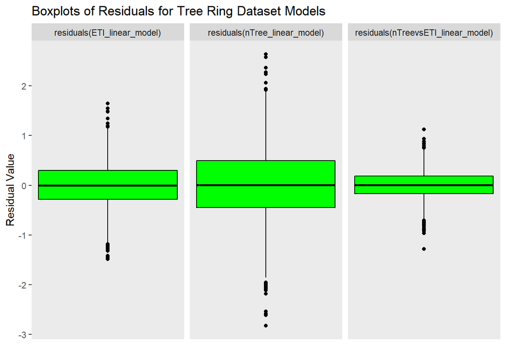

```r
#Boxplots for distribution of residuals
n_tree_res<-as.data.frame(residuals(nTree_linear_model))
ETI_res<-as.data.frame(residuals(ETI_linear_model))
n_tree_ETI_res<-as.data.frame(residuals(nTreevsETI_linear_model))
tree_ring_residuals<-cbind(n_tree_res, ETI_res, n_tree_ETI_res)
tree_ring_residuals_long<-pivot_longer(tree_ring_residuals, cols=c("residuals(nTree_linear_model)", "residuals(ETI_linear_model)", "residuals(nTreevsETI_linear_model)"), names_to="residual")

ggplot(tree_ring_residuals_long, aes(y=value))+
  geom_boxplot(col="black", fill="green")+
  ggtitle("Boxplots of Residuals for Tree Ring Dataset Models")+
  labs(y="Residual Value", x="")+
  theme(panel.grid=element_blank(), axis.text.x=element_blank(), axis.ticks.x=element_blank())+
  facet_wrap(~residual)+
  ggsave(file.path(figure_path, "tree_ring_temp_index_residuals_distribution_boxplot.pdf"))
```

Overall, we have demonstrated that the assumptions for conducting linear regression have been met, so this form of analysis is appropriate. Based off of these models, we can conclude that there is a weak negative linear relationship between year and tree ring Z-score and between year and European temperature index, and a strong positive linear relationship between tree ring Z-score and European temperature index. As noisy as the data was from the initial line plot, these conclusions were rather interesting, as we wouldn’t have thought that they would have lined up so well. However, it does make sense that vegetative growth of trees would be influenced by temperature, so this correlation is reasonable.

**Volcano Dataset**

The volcano data set contains multiple variables related to characteristics of known volcanos around the world. Some variables specify volcano location, such as `country`, `region`,`subregion`, `latitude`, and `longitude`. Other variables specify features of the volcano, such as `primary_volcano_type`, `tectonic_settings`, `elevation`, `last_eruption_year`, and various kinds of rock types that are characteristic of that volcano. Finally, human populations within 5, 10, 30, and 100 km of each volcano are provided.

*Data Cleanup*

First we cleaned up the data in the `primary_volcano_type` column by removing all duplicate values of plural classifiers (removed all (es) and (s)). Then we coverted this column, as well as `country`, `region`, `subregion`, `tectonic_settings`, `evidence_category`, `major_rock_.`, and `minor_rock_.` to factors. We also changed all the unknown `last_eruption_year` data with `NA` and converted those to numeric values. Finally, we arrange the data, create a new columns for years since the last eruption date using the `last_eruption_year` variable, and order the columns how we want them.

```r
volcano$primary_volcano_type<-gsub(".(es).", "", volcano$primary_volcano_type)
volcano$primary_volcano_type<-gsub(".(s).", "", volcano$primary_volcano_type)
volcano$primary_volcano_type<-sub("Stratovolcano.", "Stratovolcano", volcano$primary_volcano_type)
volcano$primary_volcano_type<-as.factor(volcano$primary_volcano_type)
volcano$country<-as.factor(volcano$country)
volcano$region<-as.factor(volcano$region)
volcano$subregion<-as.factor(volcano$subregion)
volcano$tectonic_settings<-as.factor(volcano$tectonic_settings)
volcano$evidence_category<-as.factor(volcano$evidence_category)
volcano$major_rock_1<-as.factor(volcano$major_rock_1)
volcano$major_rock_2<-as.factor(volcano$major_rock_2)
volcano$major_rock_3<-as.factor(volcano$major_rock_3)
volcano$major_rock_4<-as.factor(volcano$major_rock_4)
volcano$major_rock_5<-as.factor(volcano$major_rock_5)
volcano$minor_rock_1<-as.factor(volcano$minor_rock_1)
volcano$minor_rock_2<-as.factor(volcano$minor_rock_2)
volcano$minor_rock_3<-as.factor(volcano$minor_rock_3)
volcano$minor_rock_4<-as.factor(volcano$minor_rock_4)
volcano$minor_rock_5<-as.factor(volcano$minor_rock_5)
volcano$last_eruption_year<-as.numeric(gsub("Unknown", NA, volcano$last_eruption_year))
volcano<-volcano%>%
  arrange(primary_volcano_type, last_eruption_year, elevation)%>%
  mutate(years_ago=2020-last_eruption_year)
ordered_columns<-c("volcano_number", "volcano_name", "region", "subregion", "country", "latitude", "longitude", "tectonic_settings", "primary_volcano_type", "elevation", "last_eruption_year", "years_ago", "evidence_category", "population_within_5_km","population_within_10_km","population_within_30_km","population_within_100_km", "major_rock_1","major_rock_2","major_rock_3","major_rock_4","major_rock_5","minor_rock_1","minor_rock_2","minor_rock_3","minor_rock_4","minor_rock_5")
volcano<-volcano[ordered_columns]
volcano
```

```
## # A tibble: 958 x 27
##    volcano_number volcano_name region subregion country latitude longitude
##             <dbl> <chr>        <fct>  <fct>     <fct>      <dbl>     <dbl>
##  1         300023 Kurile Lake  Kamch~ Kamchatk~ Russia      51.4     157.
##  2         341093 Humeros, Los Méxic~ Mexico    Mexico      19.7     -97.4
##  3         242021 Macauley     New Z~ Kermadec~ New Ze~    -30.2    -178.
##  4         341061 Zitacuaro-V~ Méxic~ Mexico    Mexico      19.4    -100.
##  5         322160 Crater Lake  Canad~ USA (Ore~ United~     42.9    -122.
##  6         355210 Blanco, Cer~ South~ Northern~ Argent~    -26.8     -67.8
##  7         213004 Acigol-Nevs~ Medit~ Turkey    Turkey      38.5      34.6
##  8         325010 Yellowstone  Canad~ USA (Wyo~ United~     44.4    -111.
##  9         211003 Vulsini      Medit~ Italy     Italy       42.6      11.9
## 10         357061 Maule, Lagu~ South~ Central ~ Chile      -36.1     -70.5
## # ... with 948 more rows, and 20 more variables: tectonic_settings <fct>,
## #   primary_volcano_type <fct>, elevation <dbl>, last_eruption_year <dbl>,
## #   years_ago <dbl>, evidence_category <fct>, population_within_5_km <dbl>,
## #   population_within_10_km <dbl>, population_within_30_km <dbl>,
## #   population_within_100_km <dbl>, major_rock_1 <fct>, major_rock_2 <fct>,
## #   major_rock_3 <fct>, major_rock_4 <fct>, major_rock_5 <fct>,
## #   minor_rock_1 <fct>, minor_rock_2 <fct>, minor_rock_3 <fct>,
## #   minor_rock_4 <fct>, minor_rock_5 <fct>
```

```r
write.table(volcano, file.path(data_sets_path,"updated_volcano_data_set.txt"))
```

*Summary Statistics*

First, we looked at summary statistics for the numeric variables for this data set, which were `elevation`, `last_eruption_year`, `years_ago`, `population_within_5_km`, `population_within_10_km`,`population_within_30_km`, and `population_within_100_km`.. Here, we used the `summary_table()` function from the `qwraps2` package, but couldn’t get the grouping figured out properly to display the summary statistics for each variable in its own column in this package. To get around this, we just created an empty matrix, then filled it with the values from the `summary_table()` table. Following this, we compile a table of all the means of relevant numeric data from the `volcano` data set. We first looked at overall column means for these variables and saved a file of overall means titled `"volcano_dataset_overall_means.txt"`.

```r
volcano_summary <-
  list("elevation" =
         list("min_elevation"       = ~ min(volcano$elevation, na.rm=T),
              "max_elevation"       = ~ max(volcano$elevation, na.rm=T),
              "median_elevation"    = ~ median(volcano$elevation, na.rm=T),
              "mean_elevation"      = ~ mean(volcano$elevation, na.rm=T),
              "variance_elevation"  = ~ var(volcano$elevation, na.rm=T),
              "stdev_elevation"     = ~ sd(volcano$elevation, na.rm=T)),
       "last_eruption_year" =
         list("min_last_eruption_year"       = ~ min(volcano$last_eruption_year, na.rm=T),
              "max_last_eruption_year"       = ~ max(volcano$last_eruption_year, na.rm=T),
              "median_last_eruption_year"    = ~ median(volcano$last_eruption_year, na.rm=T),
              "mean_last_eruption_year"      = ~ mean(volcano$last_eruption_year, na.rm=T),
              "variance_last_eruption_year"  = ~ var(volcano$last_eruption_year, na.rm=T),
              "stdev_last_eruption_year"     = ~ sd(volcano$last_eruption_year, na.rm=T)),
       "years_ago" =
         list("min_years_ago"       = ~ min(volcano$years_ago, na.rm=T),
              "max_years_ago"       = ~ max(volcano$years_ago, na.rm=T),
              "median_years_ago"    = ~ median(volcano$years_ago, na.rm=T),
              "mean_years_ago"      = ~ mean(volcano$years_ago, na.rm=T),
              "variance_years_ago"  = ~ var(volcano$years_ago, na.rm=T),
              "stdev_years_ago"     = ~ sd(volcano$years_ago, na.rm=T)),
       "population_within_5_km" =
         list("min_population_within_5_km"       = ~ min(volcano$population_within_5_km, na.rm=T),
              "max_population_within_5_km"       = ~ max(volcano$population_within_5_km, na.rm=T),
              "median_population_within_5_km"    = ~ median(volcano$population_within_5_km, na.rm=T),
              "mean_population_within_5_km"      = ~ mean(volcano$population_within_5_km, na.rm=T),
              "variance_population_within_5_km"  = ~ var(volcano$population_within_5_km, na.rm=T),
              "stdev_population_within_5_km"     = ~ sd(volcano$population_within_5_km, na.rm=T)),
       "population_within_10_km" =
         list("min_population_within_10_km"       = ~ min(volcano$population_within_10_km, na.rm=T),
              "max_population_within_10_km"       = ~ max(volcano$population_within_10_km, na.rm=T),
              "median_population_within_10_km"    = ~ median(volcano$population_within_10_km, na.rm=T),
              "mean_population_within_10_km"      = ~ mean(volcano$population_within_10_km, na.rm=T),
              "variance_population_within_10_km"  = ~ var(volcano$population_within_10_km, na.rm=T),
              "stdev_population_within_10_km"     = ~ sd(volcano$population_within_10_km, na.rm=T)),
       "population_within_30_km" =
         list("min_population_within_30_km"       = ~ min(volcano$population_within_30_km, na.rm=T),
              "max_population_within_30_km"       = ~ max(volcano$population_within_30_km, na.rm=T),
              "median_population_within_30_km"    = ~ median(volcano$population_within_30_km, na.rm=T),
              "mean_population_within_30_km"      = ~ mean(volcano$population_within_30_km, na.rm=T),
              "variance_population_within_30_km"  = ~ var(volcano$population_within_30_km, na.rm=T),
              "stdev_population_within_30_km"     = ~ sd(volcano$population_within_30_km, na.rm=T)),
       "population_within_100_km" =
         list("min_population_within_100_km"       = ~ min(volcano$population_within_100_km, na.rm=T),
              "max_population_within_100_km"       = ~ max(volcano$population_within_100_km, na.rm=T),
              "median_population_within_100_km"    = ~ median(volcano$population_within_100_km, na.rm=T),
              "mean_population_within_100_km"      = ~ mean(volcano$population_within_100_km, na.rm=T),
              "variance_population_within_100_km"  = ~ var(volcano$population_within_100_km, na.rm=T),
              "stdev_population_within_100_km"     = ~ sd(volcano$population_within_100_km, na.rm=T))
       )
volcano_summary_table<-as.data.frame(summary_table(volcano, summaries=volcano_summary))
formatted_volcano_stats<-matrix(ncol=7, nrow=6)
colnames(formatted_volcano_stats)<-c("elevation", "last_eruption_year", "years_ago", "population_within_5_km", "population_within_10_km", "population_within_30_km", "population_within_100_km")
rownames(formatted_volcano_stats)<-c("minimum", "maximum", "median", "mean", "variance", "stdev")
formatted_volcano_stats[1:6, 1]<-volcano_summary_table[1:6, 1]
formatted_volcano_stats[1:6, 2]<-volcano_summary_table[7:12, 1]
formatted_volcano_stats[1:6, 3]<-volcano_summary_table[13:18, 1]
formatted_volcano_stats[1:6, 4]<-volcano_summary_table[19:24, 1]
formatted_volcano_stats[1:6, 5]<-volcano_summary_table[25:30, 1]
formatted_volcano_stats[1:6, 6]<-volcano_summary_table[31:36, 1]
formatted_volcano_stats[1:6, 7]<-volcano_summary_table[37:42, 1]
formatted_volcano_stats<-as.data.frame(formatted_volcano_stats)
formatted_volcano_stats
```

```
##            elevation last_eruption_year   years_ago population_within_5_km
## minimum    -2500.000        -10450.0000       0.000           0.000000e+00
## maximum     6879.000          2020.0000   12470.000           5.783287e+06
## median      1622.500          1899.0000     121.000           2.950000e+02
## mean        1867.027           730.4886    1289.511           4.786046e+04
## variance 1964330.913       5629592.7411 5629592.741           8.920316e+10
## stdev       1401.546          2372.6763    2372.676           2.986690e+05
##          population_within_10_km population_within_30_km
## minimum             0.000000e+00            0.000000e+00
## maximum             5.783287e+06            7.073814e+06
## median              1.633500e+03            1.391800e+04
## mean                6.121775e+04            3.040444e+05
## variance            9.143727e+10            5.408457e+11
## stdev               3.023860e+05            7.354221e+05
##          population_within_100_km
## minimum              0.000000e+00
## maximum              4.064011e+07
## median               3.546460e+05
## mean                 2.730174e+06
## variance             3.238726e+13
## stdev                5.690981e+06
```

```r
overall_means<-data.frame(mean(volcano$elevation),
mean(volcano$last_eruption_year, na.rm=T),
mean(volcano$years_ago, na.rm=T),
mean(volcano$population_within_5_km, na.rm=T),
mean(volcano$population_within_10_km, na.rm=T),
mean(volcano$population_within_30_km, na.rm=T),
mean(volcano$population_within_100_km, na.rm=T))
names(overall_means)<-c("elevation", "last_eruption_year", "years_ago", "population_within_5_km", "population_within_10_km","population_within_30_km", "population_within_100_km")
row.names(overall_means)<-c("overall_means")
overall_means
```

```
##               elevation last_eruption_year years_ago population_within_5_km
## overall_means  1867.027           730.4886  1289.511               47860.46
##               population_within_10_km population_within_30_km
## overall_means                61217.75                304044.4
##               population_within_100_km
## overall_means                  2730174
```

```r
write.table(overall_means, file.path(summary_text_path, "volcano_dataset_overall_means.txt"))
```

Then we looked at means based on the `primary_volcano_type` variable. We rounded each of these to whole units. Finally, we saved a file with the means for each variable by primary volcano type, titled `"volcano_dataset_means_by_primary_volcano_type.txt"`.

```r
elevation_means<-volcano%>%
  group_by(primary_volcano_type)%>%
  summarise(mean_height = mean(elevation))
elevation_means<-elevation_means[order(-elevation_means$mean_height),]
elevation_means$mean_height<-round(elevation_means$mean_height,0)

last_eruption_year_means<-volcano%>%
  group_by(primary_volcano_type)%>%
  summarise(mean_year = mean(last_eruption_year, na.rm=T))
last_eruption_year_means<-last_eruption_year_means[order(-last_eruption_year_means$mean_year),]
last_eruption_year_means$mean_year<-round(last_eruption_year_means$mean_year,0)

years_ago<-volcano%>%
  group_by(primary_volcano_type)%>%
  summarise(mean_years_ago=mean(years_ago, na.rm=T))
years_ago$mean_years_ago<-round(years_ago$mean_years_ago, 0)

five_km_pop_means<-volcano%>%
  group_by(primary_volcano_type)%>%
  summarise(mean_5km_pop=mean(population_within_5_km, na.rm=T))
five_km_pop_means$mean_5km_pop<-round(five_km_pop_means$mean_5km_pop, 0)

ten_km_pop_means<-volcano%>%
  group_by(primary_volcano_type)%>%
  summarise(mean_10km_pop=mean(population_within_10_km, na.rm=T))
ten_km_pop_means$mean_10km_pop<-round(ten_km_pop_means$mean_10km_pop, 0)

thirty_km_pop_means<-volcano%>%
  group_by(primary_volcano_type)%>%
  summarise(mean_30km_pop=mean(population_within_30_km, na.rm=T))
thirty_km_pop_means$mean_30km_pop<-round(thirty_km_pop_means$mean_30km_pop, 0)

hundred_km_pop_means<-volcano%>%
  group_by(primary_volcano_type)%>%
  summarise(mean_100km_pop=mean(population_within_100_km, na.rm=T))
hundred_km_pop_means$mean_100km_pop<-round(hundred_km_pop_means$mean_100km_pop, 0)

volcano_means_table <- merge(merge(merge(merge(merge(merge(
  elevation_means,
  last_eruption_year_means, all=T),
  years_ago, all=T),
  five_km_pop_means, all=T),
  ten_km_pop_means, all=T),
  thirty_km_pop_means, all=T),
  hundred_km_pop_means, all=T)
volcano_means_table
```

```
##    primary_volcano_type mean_height mean_year mean_years_ago mean_5km_pop
## 1               Caldera        1566       839           1181       172713
## 2               Complex        2047      1475            545        25576
## 3              Compound        2687        16           2004          996
## 4           Crater rows         423       232           1788        17713
## 5             Fure vent         948      1400            620       108557
## 6             Lava cone        2751      2020              0         4471
## 7             Lava dome        1778       310           1710       193049
## 8                  Maar        1029     -2945           4965        36782
## 9         Pyroclic cone        1596      -596           2616       138562
## 10         Pyroclicield        2156       902           1118          829
## 11               Shield        1634      -309           2329        11659
## 12        Stratovolcano        2229      1202            818         7074
## 13           Subglacial        1518     -1883           3903           12
## 14            Submarine        -741      1716            304         8602
```

[output cut: 19 more lines]

```r
write.table(volcano_means_table, file.path(summary_text_path, "volcano_dataset_means_by_primary_volcano_type.txt"))
```

*Types of Volcanoes*

Here we create a bar chart to show the types of volcanos present among the provided data. Based on this chart, we can see that, by a large margin, stratovolcanos are the most common type of volcano.

```r
type_count<-volcano %>%
  group_by(primary_volcano_type) %>%
  summarise(no_rows1 = length(primary_volcano_type))
```

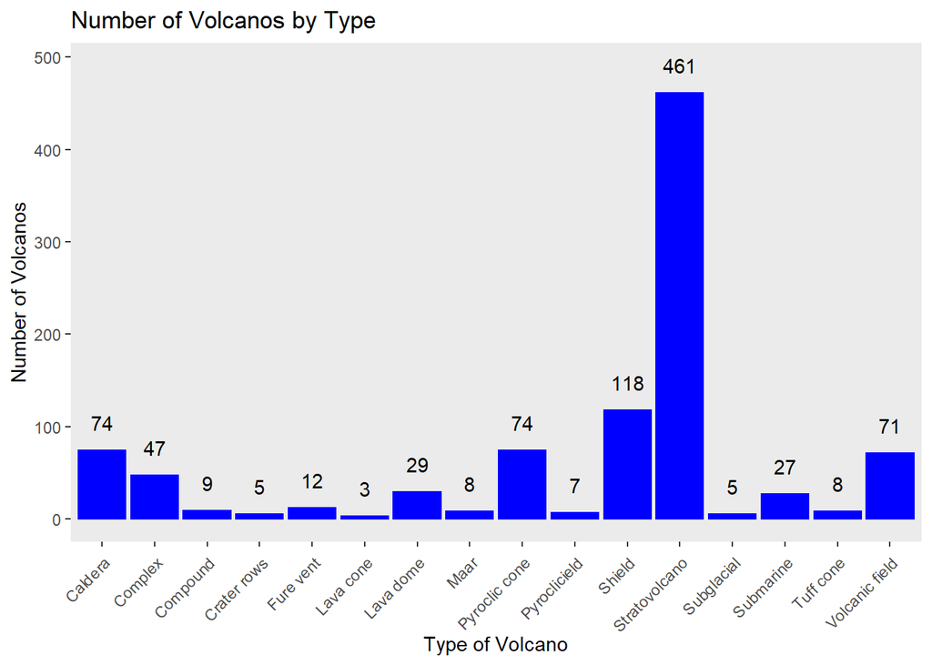

```r
ggplot(volcano, aes(x=primary_volcano_type))+
  geom_bar(col="blue", fill="blue")+
  ggtitle("Number of Volcanos by Type")+
  labs(x="Type of Volcano", y="Number of Volcanos")+
  theme(panel.grid=element_blank(), axis.text.x = element_text(angle = 45, hjust = 1, vjust = 0.95))+
  geom_text(data=type_count, aes(x=primary_volcano_type, y=no_rows1, label=no_rows1), nudge_y=30)+
  ggsave(file.path(figure_path,"volcano_count_by_type.pdf"))
```

Here we create a bar chart showing the number of volcanos in each tectonic subcategory. Here we can see that the most common tectonic setting is for subduction zone / continental crust.

```r
tectonic_count<-volcano %>%
  group_by(tectonic_settings) %>%
  summarise(no_rows3 = length(tectonic_settings))
```

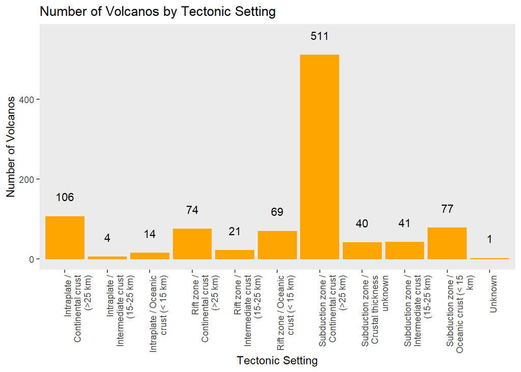

```r
ggplot(volcano, aes(x=tectonic_settings))+
  geom_bar(col="orange", fill="orange")+
  ggtitle("Number of Volcanos by Tectonic Setting")+
  labs(x="Tectonic Setting", y="Number of Volcanos")+
  theme(panel.grid=element_blank(), axis.text.x = element_text(angle = 90, hjust = 1, vjust = 0.95))+
  geom_text(data=tectonic_count ,aes(x=tectonic_settings, y=no_rows3, label=no_rows3), nudge_y=50)+
  scale_x_discrete(labels = function(tectonic_settings) str_wrap(tectonic_settings, width = 20))+
   ggsave(file.path(figure_path, "volcano_count_by_tectonic_setting.pdf"))
```

**Volcanos by Evidence Category**

```r
evidence_count<-volcano %>%
  group_by(evidence_category) %>%
  summarise(no_rows4 = length(evidence_category))
```

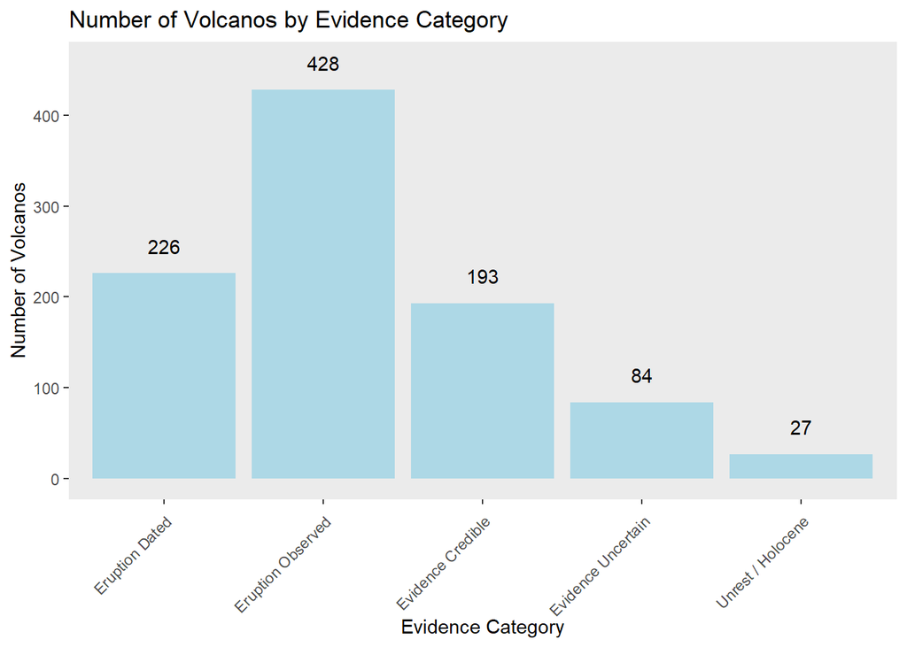

```r
ggplot(volcano, aes(x=evidence_category))+
  geom_bar(fill="light blue")+
  ggtitle("Number of Volcanos by Evidence Category")+
  labs(x="Evidence Category", y="Number of Volcanos")+
  theme(panel.grid=element_blank(), axis.text.x = element_text(angle = 45, hjust = 1, vjust = 0.95))+
  geom_text(data=evidence_count ,aes(x=evidence_category, y=no_rows4, label=no_rows4), nudge_y=30)+
   ggsave(file.path(figure_path, "volcano_count_by_evidence.pdf"))
```

*Elevation*

Here is a histogram showing the frequency of different volcano heights. The majority of volcanos are under 2,500 feet tall, with most being 1,000 to 1,500 feet tall. The data do appear to be moderately skewed to the right.

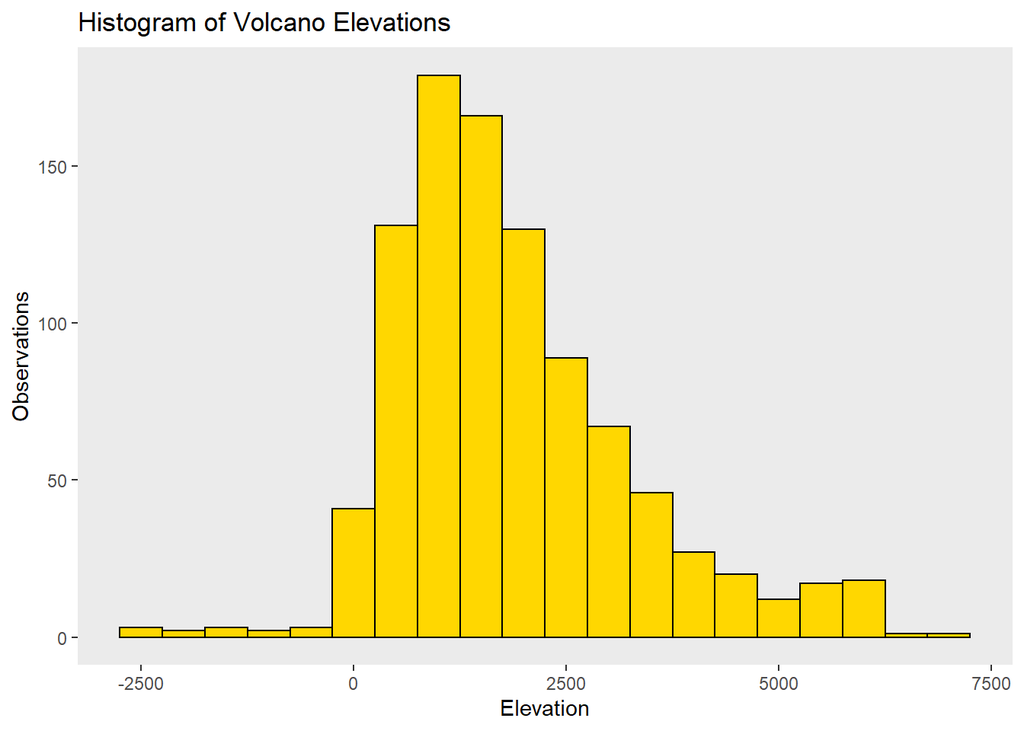

```r
ggplot(volcano, aes(x=elevation))+
  geom_histogram(binwidth=500, col="black", fill="gold")+
  ggtitle("Histogram of Volcano Elevations")+
  labs(x="Elevation", y="Observations")+
  theme(panel.grid=element_blank())+
  ggsave(file.path(figure_path, "volcano_elevation_histogram.pdf"))
```

*Eruption Dates*

This is a histogram showing the number of volcanos that have a known eruption within a certian number of years in the past. Most volcano eruptions that we are aware of fall most recently, which tracks well with the fact established above that most known volcanic eruptions fall under the “Eruption Observed” category.

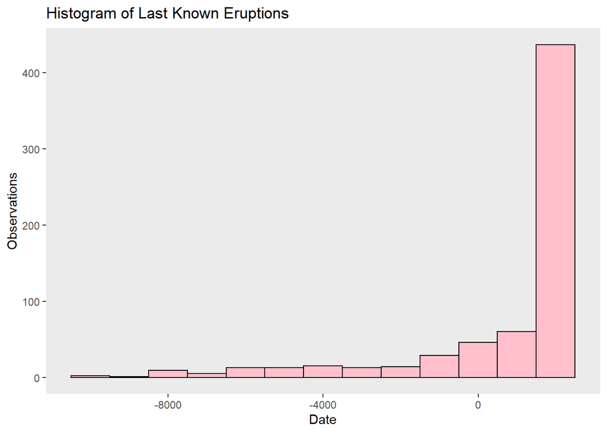

```r
ggplot(volcano, aes(x=last_eruption_year))+
  geom_histogram(binwidth=1000, color="black", fill="pink")+
  ggtitle("Histogram of Last Known Eruptions")+
  labs(x="Date", y="Observations")+
  theme(panel.grid=element_blank())+
  ggsave(file.path(figure_path, "last_eruption_year_histogram.pdf"))
```

**Multiple Comparisons through ANOVA**

For the following features we are conducting ANOVAs to identify significant differences between means for different variables. Here we use the `car` package for the Levene’s Test of Homogeneity of Variance using `leveneTest()`. Normal distribution of residuals is evaluated using the `shapiro.test()` function. Under normal circumstances, homogeneity of variance and normality of residuals would be considered prerequisite assumptions for running an ANOVA; however, for the purpose of this project, for all data, we treat the data as if the assumptions have been met, even if they are demonstrably not. Linear models are constructed, ANOVA assumptions are tested, and ANOVA is carried out. Then, boxplots are constructed to visually display the data. Tukey’s HSD is also conducted as a post hoc test using the `hsd.test()` function from the `agricolae` package and, where appropriate, is plotted on these boxplots to show groups that are signifcantly different from one another.

*Multiple Comparisons of Elevation by Volcano Type*

Here, we can see that neither normality of residuals or homogeneity of variance are met, but carry on with ANOVA for demonstration purposes. Based on the results of the ANOVA, at alpha = 0.05, we reject the null hypothesis and conclude that at least one mean elevation is different from the rest. The results of Tukey’s HSD visualized on the boxplot show that mean submarine elevation is statistically different than all but three other volcano types. However, all above-sea level volcanoes are not statistically different than one another.

```r
mean(volcano$elevation)
```

```
## [1] 1867.027
```

```r
#Ho: All mean elevations are equal among volcano types.
#HA: At least one mean elevation is different.
model1=lm(elevation~primary_volcano_type, data=volcano)
res_values1<-residuals(model1)
shapiro.test(res_values1)
```

```
##
##  Shapiro-Wilk normality test
##
## data:  res_values1
## W = 0.92207, p-value < 2.2e-16
```

```r
leveneTest(model1)
```

```
## Levene's Test for Homogeneity of Variance (center = median)
##        Df F value   Pr(>F)
## group  15  2.4039 0.001999 **
##       942
## ---
## Signif. codes:  0 '***' 0.001 '**' 0.01 '*' 0.05 '.' 0.1 ' ' 1
```

```r
elevation_anova<-aov(model1)
summary(elevation_anova)
```

```
##                       Df    Sum Sq  Mean Sq F value Pr(>F)
## primary_volcano_type  15 3.072e+08 20479080   12.27 <2e-16 ***
## Residuals            942 1.573e+09  1669510
## ---
## Signif. codes:  0 '***' 0.001 '**' 0.01 '*' 0.05 '.' 0.1 ' ' 1
```

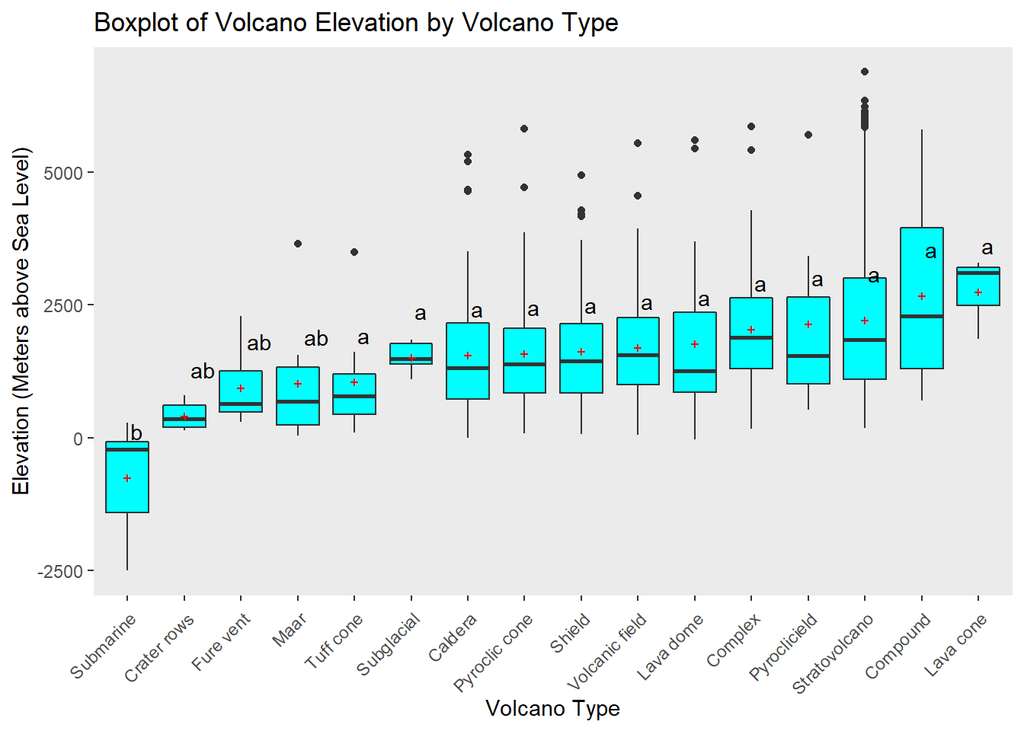

```r
hsd1=HSD.test(elevation_anova, "primary_volcano_type", group=T)


ggplot(volcano, aes(x=reorder(primary_volcano_type, elevation, na.rm=T), y=elevation))+
  geom_boxplot(fill="cyan")+
  ggtitle("Boxplot of Volcano Elevation by Volcano Type")+
  labs(y="Elevation (Meters above Sea Level)", x="Volcano Type")+
  theme(panel.grid=element_blank(), axis.text.x = element_text(angle = 45, hjust = 1, vjust = 0.95))+
  stat_summary(fun=mean, geom="point", pch="+", size=2.5, color="red", fill="red")+
  geom_text(elevation_means, mapping=aes(x=reorder(primary_volcano_type, mean_height), y=mean_height,label=hsd1$groups$groups, vjust=-2.25, hjust=-0.25))+
  ggsave(file.path(figure_path, "elevation_by_type_boxplot.pdf"))
```

*Multiple Comparisons of Last Known Eruption by Volcano Type and Tectonic Setting*

```r
#Ho: Mean last eruption year is equal among all volcano types
#HA: At least one mean eruption year is not equal
model2=lm(last_eruption_year~primary_volcano_type, data=volcano)
res_values2<-residuals(model2)
shapiro.test(res_values2)
```

```
##
##  Shapiro-Wilk normality test
##
## data:  res_values2
## W = 0.73933, p-value < 2.2e-16
```

```r
leveneTest(model2)
```

```
## Levene's Test for Homogeneity of Variance (center = median)
##        Df F value    Pr(>F)
## group  15  4.6746 1.396e-08 ***
##       641
## ---
## Signif. codes:  0 '***' 0.001 '**' 0.01 '*' 0.05 '.' 0.1 ' ' 1
```

```r
eruption_year_anova<-aov(model2)
summary(eruption_year_anova)
```

```
##                       Df    Sum Sq  Mean Sq F value  Pr(>F)
## primary_volcano_type  15 4.681e+08 31208906   6.203 2.6e-12 ***
## Residuals            641 3.225e+09  5031013
## ---
## Signif. codes:  0 '***' 0.001 '**' 0.01 '*' 0.05 '.' 0.1 ' ' 1
## 301 observations deleted due to missingness
```

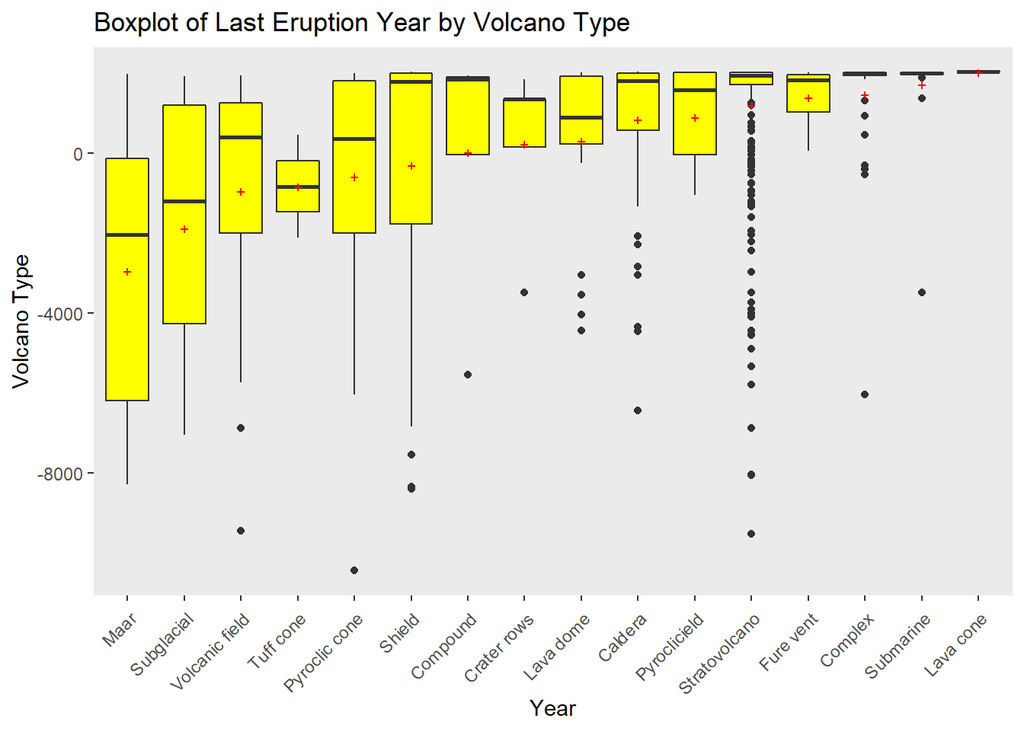

```r
hsd2=HSD.test(eruption_year_anova, "primary_volcano_type", group=T)

ggplot(volcano, aes(x=reorder(primary_volcano_type, last_eruption_year, na.rm=T), y=last_eruption_year))+
  geom_boxplot(fill="yellow")+
  ggtitle("Boxplot of Last Eruption Year by Volcano Type")+
  labs(x="Year", y="Volcano Type")+
  theme(panel.grid=element_blank(), axis.text.x = element_text(angle = 45, hjust = 1, vjust = 0.95))+
  stat_summary(fun=mean, geom="point", pch="+", size=2.5, color="red", fill="red")+
   ggsave(file.path(figure_path, "eruption_year_by_type_boxplot.pdf"))
```

Much like above, this analysis seeks to determine if volcanos in different tectonic settings, rather than just different volcano types, are more likely than others to erupt more frequently. Here again, the rationale is that the further down the y-axis, the longer it has been since an eruption. While the model assumptions are not met, in our demonstration we find that at alpha = 0.05, we reject the null hypothesis and conclude that at least one mean last eruption year is different from the rest among tectonic settings.

```r
last_eruption_year_means2<-volcano%>%
  group_by(tectonic_settings)%>%
  summarise(mean_year = mean(last_eruption_year, na.rm=T))%>%
  filter(tectonic_settings!="Unknown")
last_eruption_year_means2<-last_eruption_year_means2[order(-last_eruption_year_means2$mean_year),]
last_eruption_year_means2$mean_year<-round(last_eruption_year_means2$mean_year,0)

#Ho: Mean last eruption year is equal among all tectonic settings.
#HA: At least one mean eruption year is not equal.
model3=lm(last_eruption_year~tectonic_settings, data=volcano)
res_values3<-residuals(model3)
shapiro.test(res_values3)
```

```
##
##  Shapiro-Wilk normality test
##
## data:  res_values3
## W = 0.74154, p-value < 2.2e-16
```

```r
leveneTest(model3)
```

```
## Levene's Test for Homogeneity of Variance (center = median)
##        Df F value   Pr(>F)
## group   9  7.6416 1.05e-10 ***
##       647
## ---
## Signif. codes:  0 '***' 0.001 '**' 0.01 '*' 0.05 '.' 0.1 ' ' 1
```

```r
eruption_tectonic_anova<-aov(model3)
summary(eruption_tectonic_anova)
```

```
##                    Df    Sum Sq  Mean Sq F value   Pr(>F)
## tectonic_settings   9 4.237e+08 47074012   9.316 2.27e-13 ***
## Residuals         647 3.269e+09  5053086
## ---
## Signif. codes:  0 '***' 0.001 '**' 0.01 '*' 0.05 '.' 0.1 ' ' 1
## 301 observations deleted due to missingness
```

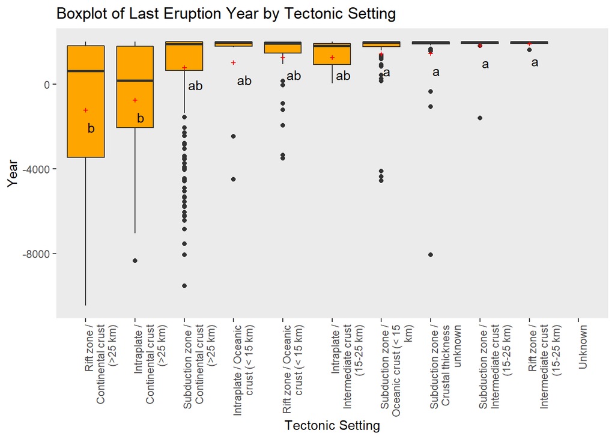

```r
hsd3=HSD.test(eruption_tectonic_anova, "tectonic_settings", group=T)

ggplot(volcano, aes(x=reorder(tectonic_settings, last_eruption_year, na.rm=T), y=last_eruption_year))+
  geom_boxplot(fill="orange")+
  ggtitle("Boxplot of Last Eruption Year by Tectonic Setting")+
  labs(x="Tectonic Setting", y="Year")+
  theme(panel.grid=element_blank(), axis.text.x = element_text(angle = 90, hjust = 1, vjust = 0.95))+
  stat_summary(fun=mean, geom="point", pch="+", size=2.5, color="red", fill="red")+
  geom_text(last_eruption_year_means2, mapping=aes(x=reorder(tectonic_settings, mean_year), y=mean_year,label=hsd3$groups$groups, vjust=2.25, hjust=-0.25))+
  scale_x_discrete(labels = function(tectonic_settings) str_wrap(tectonic_settings, width = 20))+
   ggsave(file.path(figure_path, "last_eruption_year_by_tectonic_setting.pdf"))
```

*Populations within Specified Radius of Volcano Types and Multiple Comparisions*

Here, we are showing the number of people that live within 5, 10, 30, and 100 km of different volcano types. While we had initially planned to show this as boxplot data, there were several extreme outliers that were compressing the data. While we could have adjusted the axes to exclude these, we did not feel that this would represent the data well. Instead, we plot mean populations living within the specified range of each volcano type as bar charts. A word of caution for the bar plots that follow, because the outliers were so severe, they do skew the mean values reported. After showing these bar charts of mean values, we look for significant differences between means using ANOVA, then conduct Tukey’s HSD as a post hoc test. Here again, we check the assumptions for each ANOVA, but treat all analyses as if the assumptions have been met for demonstration purposes.

Based on each ANOVA result, at alpha = 0.05, we reject each null hypothesis, and conclude that at each distance, there is a significant difference in the mean population.

```r
population_means_by_volcano_type<-group_by(volcano, primary_volcano_type) %>%
  summarize(mean_population_within_5_km = mean(population_within_5_km), mean_population_within_10_km = mean(population_within_10_km), mean_population_within_30_km = mean(population_within_30_km), mean_population_within_100_km = mean(population_within_100_km))
```

```r
population_means_by_volcano_type[,2:5]<-round(population_means_by_volcano_type[,2:5],digits=0)

ggplot(population_means_by_volcano_type, aes(x=primary_volcano_type, y=mean_population_within_5_km))+
  geom_col(fill="red")+
  ggtitle("Mean Population Living within 5km of Volcanos by Volcano Type")+
  labs(x="Volcano Type", y="Mean Population within 5km")+
  theme(panel.grid=element_blank(), axis.text.x = element_text(angle = 45, hjust = 1, vjust = 0.95))+
  geom_text(data=population_means_by_volcano_type, aes(x=primary_volcano_type, y=mean_population_within_5_km, label=mean_population_within_5_km), nudge_y=10000, size=3)+
  ggsave(file.path(figure_path, "mean_5km_pop_by_type_barplot.pdf"))
ggplot(population_means_by_volcano_type, aes(x=primary_volcano_type, y=mean_population_within_10_km))+
  geom_col(fill="green")+
  ggtitle("Mean Population Living within 10km of Volcanos by Volcano Type")+
  labs(x="Volcano Type", y="Mean Population within 10km")+
  theme(panel.grid=element_blank(), axis.text.x = element_text(angle = 45, hjust = 1, vjust = 0.95))+
  geom_text(data=population_means_by_volcano_type, aes(x=primary_volcano_type, y=mean_population_within_10_km, label=mean_population_within_10_km), nudge_y=10000, size=3)+
  ggsave(file.path(figure_path, "mean_10km_pop_by_type_barplot.pdf"))
ggplot(population_means_by_volcano_type, aes(x=primary_volcano_type, y=mean_population_within_30_km))+
  geom_col(fill="orange")+
  ggtitle("Mean Population Living within 30km of Volcanos by Volcano Type")+
  labs(x="Volcano Type", y="Mean Population within 30km")+
  theme(panel.grid=element_blank(), axis.text.x = element_text(angle = 45, hjust = 1, vjust = 0.95))+
  geom_text(data=population_means_by_volcano_type, aes(x=primary_volcano_type, y=mean_population_within_30_km, label=mean_population_within_30_km), nudge_y=25000, size=3)+
  ggsave(file.path(figure_path, "mean_30km_pop_by_type_barplot.pdf"))
ggplot(population_means_by_volcano_type, aes(x=primary_volcano_type, y=mean_population_within_100_km))+
  geom_col(fill="blue")+
  ggtitle("Mean Population Living within 100km of Volcanos by Volcano Type")+
  labs(x="Volcano Type", y="Mean Population within 100km")+
  theme(panel.grid=element_blank(), axis.text.x = element_text(angle = 45, hjust = 1, vjust = 0.95))+
  geom_text(data=population_means_by_volcano_type, aes(x=primary_volcano_type, y=mean_population_within_100_km, label=mean_population_within_100_km), nudge_y=175000, size=3)+
ggsave(file.path(figure_path, "mean_100km_pop_by_type_barplot.pdf"))
#5km population means
#Ho: All populations are equal among volcano types
#HA: At least one mean population is different
model4=lm(population_within_5_km~primary_volcano_type, data=volcano)
res_values4<-residuals(model4)
shapiro.test(res_values4)
```

```
##
##  Shapiro-Wilk normality test
##
## data:  res_values4
## W = 0.21607, p-value < 2.2e-16
```

```r
leveneTest(model4)
```

```
## Levene's Test for Homogeneity of Variance (center = median)
##        Df F value    Pr(>F)
## group  15   2.963 0.0001214 ***
##       942
## ---
## Signif. codes:  0 '***' 0.001 '**' 0.01 '*' 0.05 '.' 0.1 ' ' 1
```

```r
five_km_anova<-aov(model4)
summary(five_km_anova)
```

```
##                       Df    Sum Sq   Mean Sq F value  Pr(>F)
## primary_volcano_type  15 3.869e+12 2.579e+11   2.981 0.00011 ***
## Residuals            942 8.150e+13 8.652e+10
## ---
## Signif. codes:  0 '***' 0.001 '**' 0.01 '*' 0.05 '.' 0.1 ' ' 1
```

```r
hsd4=HSD.test(five_km_anova, "primary_volcano_type", group=T)

#10km population means
#Ho: All populations are equal among volcano types
#HA: At least one mean population is different
model5=lm(population_within_10_km~primary_volcano_type, data=volcano)
res_values5<-residuals(model5)
shapiro.test(res_values5)
```

```
##
##  Shapiro-Wilk normality test
##
## data:  res_values5
## W = 0.25479, p-value < 2.2e-16
```

```r
leveneTest(model5)
```

```
## Levene's Test for Homogeneity of Variance (center = median)
##        Df F value   Pr(>F)
## group  15  2.4694 0.001457 **
##       942
## ---
## Signif. codes:  0 '***' 0.001 '**' 0.01 '*' 0.05 '.' 0.1 ' ' 1
```

```r
ten_km_anova<-aov(model5)
summary(ten_km_anova)
```

```
##                       Df    Sum Sq   Mean Sq F value  Pr(>F)
## primary_volcano_type  15 3.333e+12 2.222e+11   2.487 0.00134 **
## Residuals            942 8.417e+13 8.936e+10
## ---
## Signif. codes:  0 '***' 0.001 '**' 0.01 '*' 0.05 '.' 0.1 ' ' 1
```

```r
hsd5=HSD.test(ten_km_anova, "primary_volcano_type", group=T)

#30km population means
#Ho: All populations are equal among volcano types
#HA: At least one mean population is different
model6=lm(population_within_30_km~primary_volcano_type, data=volcano)
res_values6<-residuals(model6)
shapiro.test(res_values6)
```

```
##
##  Shapiro-Wilk normality test
##
## data:  res_values6
## W = 0.53786, p-value < 2.2e-16
```

```r
leveneTest(model6)
```

```
## Levene's Test for Homogeneity of Variance (center = median)
##        Df F value   Pr(>F)
## group  15  2.0955 0.008433 **
##       942
## ---
## Signif. codes:  0 '***' 0.001 '**' 0.01 '*' 0.05 '.' 0.1 ' ' 1
```

```r
thirty_km_anova<-aov(model6)
summary(thirty_km_anova)
```

```
##                       Df    Sum Sq   Mean Sq F value Pr(>F)
## primary_volcano_type  15 1.694e+13 1.129e+12   2.124 0.0074 **
## Residuals            942 5.007e+14 5.315e+11
## ---
## Signif. codes:  0 '***' 0.001 '**' 0.01 '*' 0.05 '.' 0.1 ' ' 1
```

```r
hsd6=HSD.test(thirty_km_anova, "primary_volcano_type", group=T)

#100km population means
#Ho: All populations are equal among volcano types
#HA: At least one mean population is different
model7=lm(population_within_100_km~primary_volcano_type, data=volcano)
res_values7<-residuals(model7)
shapiro.test(res_values7)
```

```
##
##  Shapiro-Wilk normality test
##
## data:  res_values7
## W = 0.60855, p-value < 2.2e-16
```

```r
leveneTest(model7)
```

```
## Levene's Test for Homogeneity of Variance (center = median)
##        Df F value    Pr(>F)
## group  15  2.8804 0.0001859 ***
##       942
## ---
## Signif. codes:  0 '***' 0.001 '**' 0.01 '*' 0.05 '.' 0.1 ' ' 1
```

```r
hundred_km_anova<-aov(model7)
summary(hundred_km_anova)
```

```
##                       Df    Sum Sq   Mean Sq F value   Pr(>F)
## primary_volcano_type  15 1.356e+15 9.043e+13   2.874 0.000192 ***
## Residuals            942 2.964e+16 3.146e+13
## ---
## Signif. codes:  0 '***' 0.001 '**' 0.01 '*' 0.05 '.' 0.1 ' ' 1
```

```r
hsd7=HSD.test(hundred_km_anova, "primary_volcano_type", group=T)
```

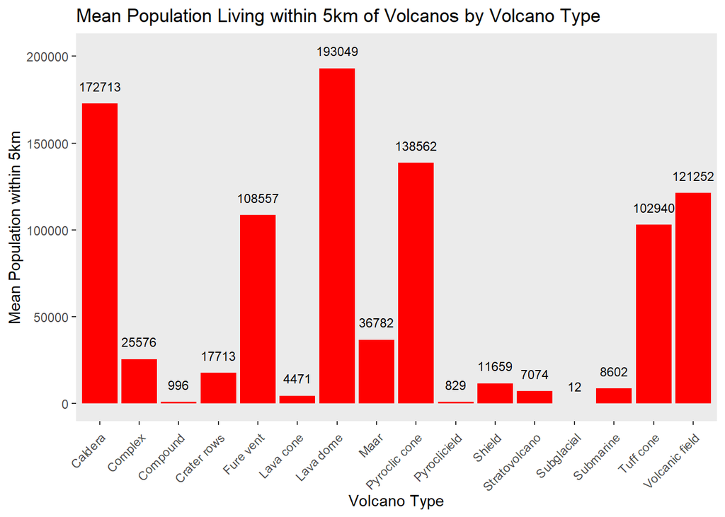

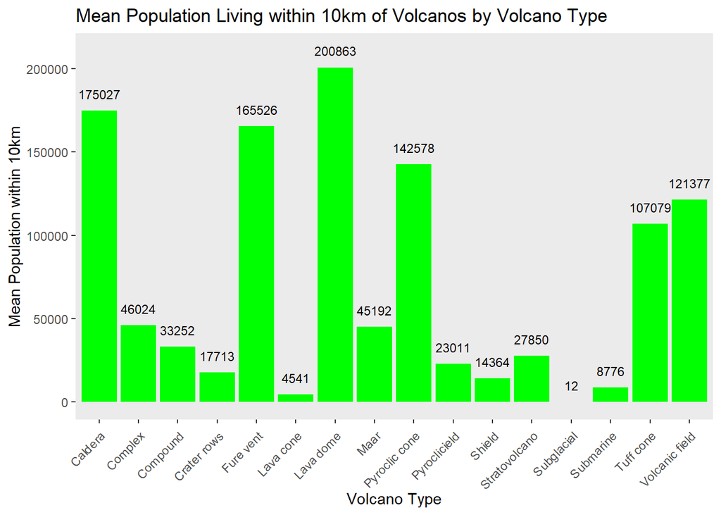

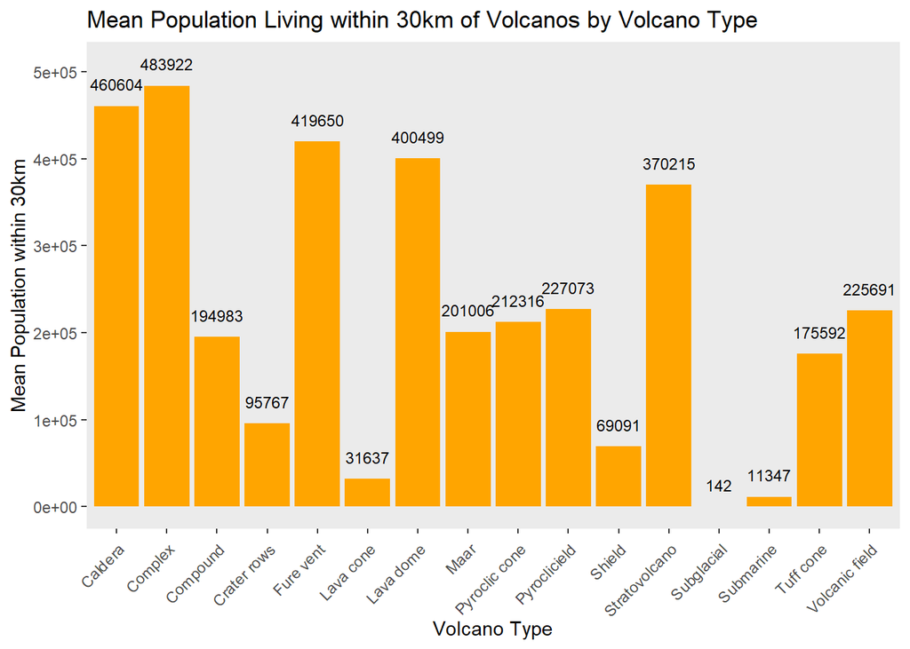

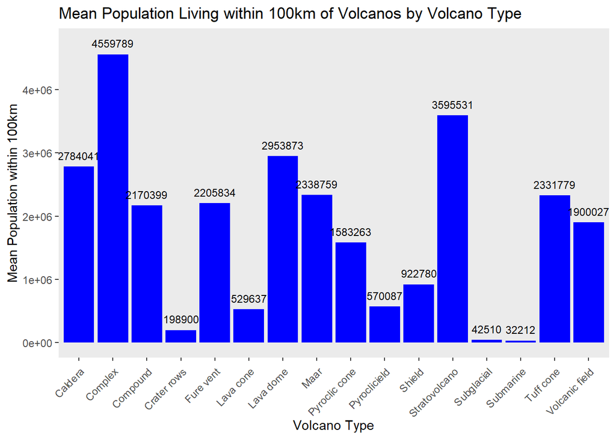

*Linear Regression and Correlation of Volcano Elevation with Last Known Eruption Year*

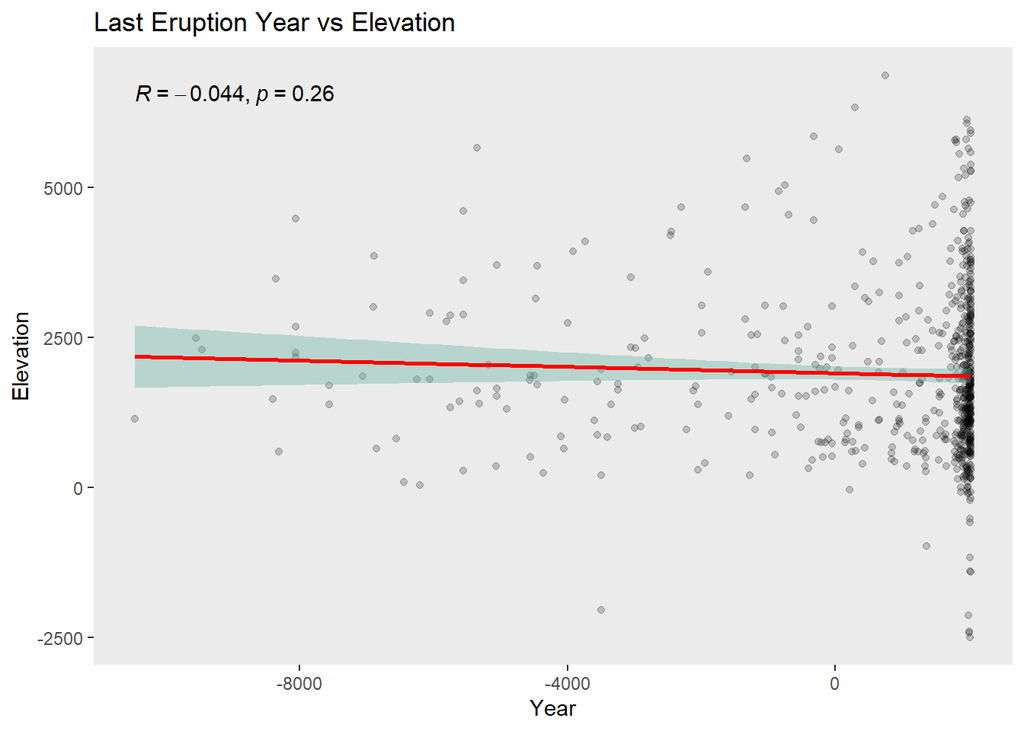

```r
#Ho: Slope = 0 (no linear relationship)
#HA: Slope not equal to 0 (linear relationship)
ggplot(volcano, aes(x=last_eruption_year, y=elevation))+
  geom_point(alpha=1/5)+
  ggtitle("Last Eruption Year vs Elevation")+
  labs(x="Year", y="Elevation")+
  theme(panel.grid=element_blank())+
  stat_cor()+
  geom_smooth(method=lm , color="red", fill="#69b3a2", se=TRUE)+
  ggsave(file.path(figure_path, "elevation_vs_eruption_year_correlation.pdf"))
```

*Global Volcano Locations*

Here we create a bar chart showing the number of volcanos present in various regions of the world. Since actual latitude and longitude coordinates were provided in this data file, following this regional grouping bar chart, we used the `threejs` package to plot each of the coordinates on a global map. Height of individual bars on the map represent volcano elevation, while heatmap colors indicate the number of years since the last known eruption (white = most recent, red = most distant past). The globe can be toggled for a 360 degree view of the globe using the cursor.

```r
region_count<-volcano %>%
  group_by(region) %>%
  summarise(no_rows2 = length(region))
```

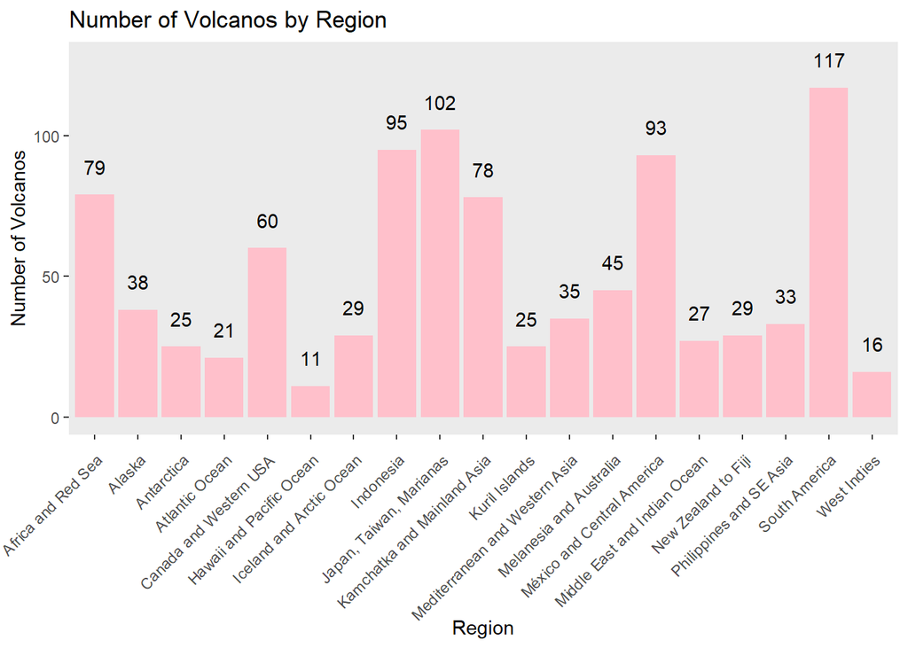

```r
ggplot(volcano, aes(x=region))+
  geom_bar(fill="pink")+
  ggtitle("Number of Volcanos by Region")+
  labs(x="Region", y="Number of Volcanos")+
  theme(panel.grid=element_blank(), axis.text.x = element_text(angle = 45, hjust = 1, vjust = 0.95))+
  geom_text(data=region_count ,aes(x=region, y=no_rows2, label=no_rows2), nudge_y=10)+
  ggsave(file.path(figure_path, "volcano_count_by_region.pdf"))
```

```r
for_globe<-volcano[,c("latitude", "longitude", "years_ago", "elevation")]
colors=as.numeric(cut(for_globe$years_ago,
                      breaks=1000, include.lowest=T, na.rm=T))
colors=heat.colors(colors)
globejs(lat=for_globe$latitude, long=for_globe$longitude, val=(0.025*for_globe$elevation), color=colors, atmosphere=T, pointsize=0.75, emissive=T)
```

[interactive chart not shown]

**Eruptions Dataset**

The `eruptions` data set contains information related to volcanic eruptions for individually named volcanos. Among this information is the VEI, or volcanic explosivity index, which is a measure of the intensity of past volcanic eruptions. Additionally, start and end dates for eruptions are provided with individual columns for day, month, and year. Location is provided with latitude and longitude, while observations such as type of methodology used for dating past eruptions is also included. For the purpose of this project, we are focusing primarily on the main numeric data in this file, the VEI.

*Eruption Intensity by VEI*

Plotted below is a simple histogram showing the distribution of VEI across recorded volcanic eruptions. As seen in the histogram, most past eruptions have a VEI of 2, which is toward the low end of the scale. There is some right skew to the data as well.

```r
mean(eruptions$vei, na.rm=T)
```

```
## [1] 1.947897
```

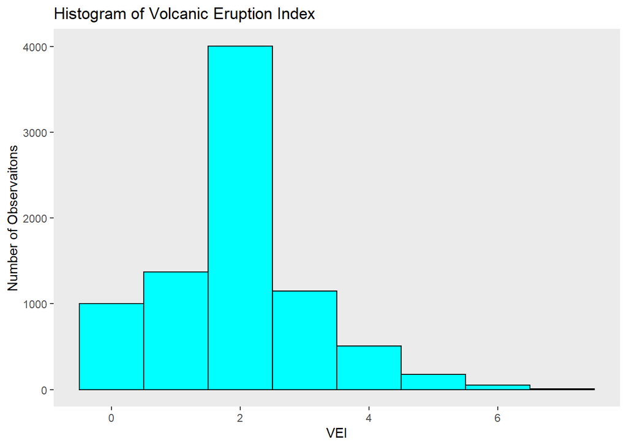

```r
ggplot(eruptions, aes(x=vei))+
  geom_histogram(binwidth=1, col="black", fill="cyan")+
  ggtitle("Histogram of Volcanic Eruption Index")+
  labs(x="VEI", y="Number of Observaitons")+
  theme(panel.grid = element_blank())+
  ggsave(file.path(figure_path, "vei_histogram.pdf"))
```

*VEI Visualized over Longitude and Latitude*

These two count graphs provide a visualization of the number of volcanoes, and their respective VEI, plotted over Longitude and Latitude. this is achieved by simply plotting the VEI against the data points for Latitude and Longitude respectively. The size of each point represents the number of volcanoes of a certain VEI at a certain Latitude or Longitude. Using these plots we can see the distribution of intense volcanoes between the Eastern and Western hemispheres, as well as the Northern and Southern hemispheres.

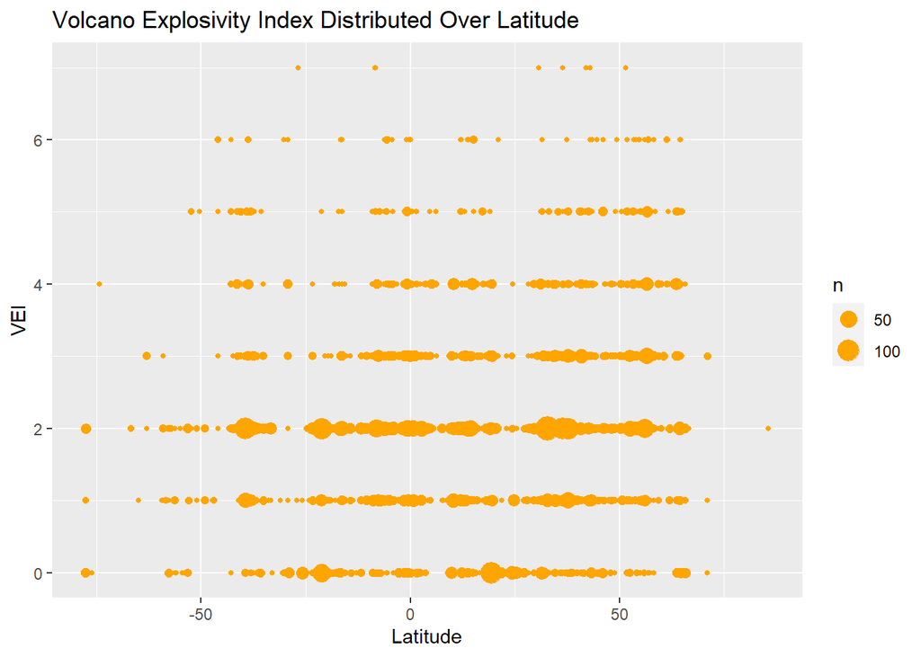

```r
#y axis is intensity and the x axis is longitude, size of dot = the number of observations at that given latitude
ggplot(eruptions, aes(x=latitude, y=vei))+
  geom_count(na.rm = T, col = "orange")+
  ggtitle("Volcano Explosivity Index Distributed Over Latitude")+
  labs(x="Latitude", y="VEI")+
  ggsave(file.path(figure_path, "vei_by_latitude.pdf"))
```

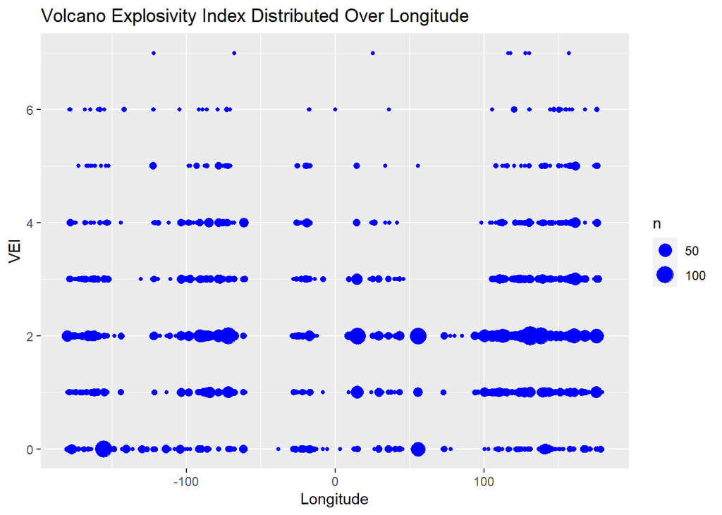

```r
ggplot(eruptions, aes(x=longitude, y=vei))+
  geom_count(na.rm = T, col = "blue")+
  ggtitle("Volcano Explosivity Index Distributed Over Longitude")+
  labs(x="Longitude", y="VEI")+
  ggsave(file.path(figure_path, "vei_by_longitude.pdf"))
```

*Eruption Length Categorized by VEI*